# DATA 621 – Business Analytics and Data Mining - HW 4 - INSURANCE EVALUATION

Enid Roman

2023-11-29

## **INTRODUCTION**

In this assignment, I will explore, analyze and model a data set containing approximately 8000 records representing a customer at an auto insurance company. Each record has two response variables. The first response variable, TARGET_FLAG, is a 1 or a 0. A “1” means that the person was in a car crash. A zero means that the person was not in a car crash. The second response variable is TARGET_AMT. This value is zero if the person did not crash their car. But if they did crash their car, this number will be a value greater than zero.

My objective is to build multiple linear regression and binary logistic regression models on the training data to predict the probability that a person will crash their car and also the amount of money it will cost if the person does crash their car. I can only use the variables given to me (or variables that I derive from the variables provided). Below is a short description of the variables of interest in the data set:

| VARIABLE NAME | DEFINITION | THEORETICAL EFFECT |
| --- | --- | --- |
| INDEX | Identification Variable (do not use) | None |
| TARGET_FLAG | Was Car in a crash? 1=YES 0=NO | None |
| TARGET_AMT | If car was in a crash, what was the cost | None |
| AGE | Age of Driver | Very young people tend to be risky. Maybe very old people also. |
| BLUEBOOK | Value of Vehicle | Unknown effect on probability of collision, but probably effect the payout if there is a crash. |
| CAR_AGE | Vehicle Age | Unknown effect on probability of collision, but probably effect the payout if there is a crash. |
| CAR_TYPE | Type of Car | Unknown effect on probability of collision, but probably effect the payout if there is a crash. |
| CAR_USE | Vehicle Use | Commercial vehicles are driven more, so might increase probability of collision. |
| CLM_FREQ | # Claims (Past 5 Years) | The more claims you filed in the past, the more you are likely to file in the future. |
| EDUCATION | Max Education Level | Unknown effect, but in theory more educated people tend to drive more safely. |
| HOMEKIDS | # Children at Home | Unknown effect |
| HOME_VAL | Home Value | In theory, home owners tend to drive more responsibly. |
| INCOME | Income | In theory, rich people tend to get into fewer crashes. |
| JOB | Job Category | In theory, white collar jobs tend to be safer. |
| KIDSDRIV | # Driving Children | When teenagers drive your car, you are more likely to get into crashes. |
| MSTATUS | Marital Status | In theory, married people drive more safely. |
| MVR_PTS | Motor Vehicle Record Points | If you get lots of traffic tickets, you tend to get into more crashes. |
| OLDCLAIM | Total Claims (Past 5 Years) | If your total payout over the past five years was high, this suggests future payouts will be high. |
| PARENT1 | Single Parent | Unknown effect. |
| RED_CAR | A Red Car | Urban legend says that red cars (especially red sports cars) are more risky. Is that true? |
| REVOKED | License Revoked (Past 7 Years) | If your license was revoked in the past 7 years, you probably are a more risky driver. |
| SEX | Gender | Urban legend says that women have less crashes then men. Is that true? |
| TIF | Time in Force | People who have been customers for a long time are usually more safe. |
| TRAVTIME | Distance to Work | Long drives to work usually suggest greater risk. |
| URBANICITY | Home/Work Area | Unknown |
| YOJ | Years on Job | People who stay at a job for a long time are usually more safe. |

## **DATA EXPLORATION**

### **DATA SUMMARY**

```
##             vars    n    mean      sd median trimmed     mad min      max
## INDEX          1 8161 5151.87 2978.89   5133 5151.93 3841.42   1  10302.0
## TARGET_FLAG    2 8161    0.26    0.44      0    0.20    0.00   0      1.0
## TARGET_AMT     3 8161 1504.32 4704.03      0  593.71    0.00   0 107586.1
## KIDSDRIV       4 8161    0.17    0.51      0    0.03    0.00   0      4.0
## AGE            5 8155   44.79    8.63     45   44.83    8.90  16     81.0
## HOMEKIDS       6 8161    0.72    1.12      0    0.50    0.00   0      5.0
## YOJ            7 7707   10.50    4.09     11   11.07    2.97   0     23.0
## INCOME*        8 8161 2875.55 2090.68   2817 2816.95 2799.15   1   6613.0
## PARENT1*       9 8161    1.13    0.34      1    1.04    0.00   1      2.0
## HOME_VAL*     10 8161 1684.89 1697.38   1245 1516.50 1842.87   1   5107.0
## MSTATUS*      11 8161    1.40    0.49      1    1.38    0.00   1      2.0
## SEX*          12 8161    1.54    0.50      2    1.55    0.00   1      2.0
## EDUCATION*    13 8161    3.09    1.44      3    3.11    1.48   1      5.0
## JOB*          14 8161    5.69    2.68      6    5.81    2.97   1      9.0
## TRAVTIME      15 8161   33.49   15.91     33   33.00   16.31   5    142.0
## CAR_USE*      16 8161    1.63    0.48      2    1.66    0.00   1      2.0
## BLUEBOOK*     17 8161 1283.62  893.51   1124 1259.57 1132.71   1   2789.0
## TIF           18 8161    5.35    4.15      4    4.84    4.45   1     25.0
## CAR_TYPE*     19 8161    3.53    1.97      3    3.54    2.97   1      6.0
## RED_CAR*      20 8161    1.29    0.45      1    1.24    0.00   1      2.0
## OLDCLAIM*     21 8161  552.27  862.20      1  380.32    0.00   1   2857.0
## CLM_FREQ      22 8161    0.80    1.16      0    0.59    0.00   0      5.0
## REVOKED*      23 8161    1.12    0.33      1    1.03    0.00   1      2.0
## MVR_PTS       24 8161    1.70    2.15      1    1.31    1.48   0     13.0
## CAR_AGE       25 7651    8.33    5.70      8    7.96    7.41  -3     28.0
## URBANICITY*   26 8161    1.20    0.40      1    1.13    0.00   1      2.0
## target_amt*   27 8161  256.71  512.57      1  125.62    0.00   1   1949.0
## target*       28 8161    1.26    0.44      1    1.20    0.00   1      2.0
##                range  skew kurtosis    se
## INDEX        10301.0  0.00    -1.20 32.97
## TARGET_FLAG      1.0  1.07    -0.85  0.00
## TARGET_AMT  107586.1  8.71   112.29 52.07
## KIDSDRIV         4.0  3.35    11.78  0.01
## AGE             65.0 -0.03    -0.06  0.10
## HOMEKIDS         5.0  1.34     0.65  0.01
## YOJ             23.0 -1.20     1.18  0.05
## INCOME*       6612.0  0.11    -1.29 23.14
## PARENT1*         1.0  2.17     2.73  0.00
## HOME_VAL*     5106.0  0.52    -1.18 18.79
## MSTATUS*         1.0  0.41    -1.83  0.01
## SEX*             1.0 -0.14    -1.98  0.01
## EDUCATION*       4.0  0.12    -1.38  0.02
## JOB*             8.0 -0.31    -1.22  0.03
## TRAVTIME       137.0  0.45     0.66  0.18
## CAR_USE*         1.0 -0.53    -1.72  0.01
## BLUEBOOK*     2788.0  0.25    -1.36  9.89
## TIF             24.0  0.89     0.42  0.05
## CAR_TYPE*        5.0  0.00    -1.52  0.02
## RED_CAR*         1.0  0.92    -1.16  0.01
## OLDCLAIM*     2856.0  1.31     0.25  9.54
## CLM_FREQ         5.0  1.21     0.28  0.01
## REVOKED*         1.0  2.30     3.30  0.00
## MVR_PTS         13.0  1.35     1.38  0.02
## CAR_AGE         31.0  0.28    -0.75  0.07
## URBANICITY*      1.0  1.46     0.15  0.00
## target_amt*   1948.0  1.90     2.25  5.67
## target*          1.0  1.07    -0.85  0.00
```

```
##      INDEX        TARGET_FLAG       TARGET_AMT        KIDSDRIV
##  Min.   :    1   Min.   :0.0000   Min.   :     0   Min.   :0.0000
##  1st Qu.: 2559   1st Qu.:0.0000   1st Qu.:     0   1st Qu.:0.0000
##  Median : 5133   Median :0.0000   Median :     0   Median :0.0000
##  Mean   : 5152   Mean   :0.2638   Mean   :  1504   Mean   :0.1711
##  3rd Qu.: 7745   3rd Qu.:1.0000   3rd Qu.:  1036   3rd Qu.:0.0000
##  Max.   :10302   Max.   :1.0000   Max.   :107586   Max.   :4.0000
##
##       AGE           HOMEKIDS           YOJ          INCOME
##  Min.   :16.00   Min.   :0.0000   Min.   : 0.0   Length:8161
##  1st Qu.:39.00   1st Qu.:0.0000   1st Qu.: 9.0   Class :character
##  Median :45.00   Median :0.0000   Median :11.0   Mode  :character
##  Mean   :44.79   Mean   :0.7212   Mean   :10.5
##  3rd Qu.:51.00   3rd Qu.:1.0000   3rd Qu.:13.0
##  Max.   :81.00   Max.   :5.0000   Max.   :23.0
##  NA's   :6                        NA's   :454
##    PARENT1            HOME_VAL           MSTATUS              SEX
##  Length:8161        Length:8161        Length:8161        Length:8161
##  Class :character   Class :character   Class :character   Class :character
##  Mode  :character   Mode  :character   Mode  :character   Mode  :character
##
##
##
##
##   EDUCATION             JOB               TRAVTIME        CAR_USE
##  Length:8161        Length:8161        Min.   :  5.00   Length:8161
##  Class :character   Class :character   1st Qu.: 22.00   Class :character
##  Mode  :character   Mode  :character   Median : 33.00   Mode  :character
##                                        Mean   : 33.49
##                                        3rd Qu.: 44.00
##                                        Max.   :142.00
##
##    BLUEBOOK              TIF           CAR_TYPE           RED_CAR
##  Length:8161        Min.   : 1.000   Length:8161        Length:8161
##  Class :character   1st Qu.: 1.000   Class :character   Class :character
##  Mode  :character   Median : 4.000   Mode  :character   Mode  :character
##                     Mean   : 5.351
##                     3rd Qu.: 7.000
##                     Max.   :25.000
##
##    OLDCLAIM            CLM_FREQ        REVOKED             MVR_PTS
##  Length:8161        Min.   :0.0000   Length:8161        Min.   : 0.000
##  Class :character   1st Qu.:0.0000   Class :character   1st Qu.: 0.000
##  Mode  :character   Median :0.0000   Mode  :character   Median : 1.000
##                     Mean   :0.7986                      Mean   : 1.696
##                     3rd Qu.:2.0000                      3rd Qu.: 3.000
##                     Max.   :5.0000                      Max.   :13.000
##
##     CAR_AGE        URBANICITY
##  Min.   :-3.000   Length:8161
##  1st Qu.: 1.000   Class :character
##  Median : 8.000   Mode  :character
##  Mean   : 8.328
##  3rd Qu.:12.000
##  Max.   :28.000
##  NA's   :510
```

### **DATA STRUCTURE**

```
## 'data.frame':    8161 obs. of  26 variables:
##  $ INDEX      : int  1 2 4 5 6 7 8 11 12 13 ...
##  $ TARGET_FLAG: int  0 0 0 0 0 1 0 1 1 0 ...
##  $ TARGET_AMT : num  0 0 0 0 0 ...
##  $ KIDSDRIV   : int  0 0 0 0 0 0 0 1 0 0 ...
##  $ AGE        : int  60 43 35 51 50 34 54 37 34 50 ...
##  $ HOMEKIDS   : int  0 0 1 0 0 1 0 2 0 0 ...
##  $ YOJ        : int  11 11 10 14 NA 12 NA NA 10 7 ...
##  $ INCOME     : chr  "$67,349 " "$91,449 " "$16,039 " "" ...
##  $ PARENT1    : chr  "No" "No" "No" "No" ...
##  $ HOME_VAL   : chr  "$0 " "$257,252 " "$124,191 " "$306,251 " ...
##  $ MSTATUS    : chr  "z_No" "z_No" "Yes" "Yes" ...
##  $ SEX        : chr  "M" "M" "z_F" "M" ...
##  $ EDUCATION  : chr  "PhD" "z_High School" "z_High School" "<High School" ...
##  $ JOB        : chr  "Professional" "z_Blue Collar" "Clerical" "z_Blue Collar" ...
##  $ TRAVTIME   : int  14 22 5 32 36 46 33 44 34 48 ...
##  $ CAR_USE    : chr  "Private" "Commercial" "Private" "Private" ...
##  $ BLUEBOOK   : chr  "$14,230 " "$14,940 " "$4,010 " "$15,440 " ...
##  $ TIF        : int  11 1 4 7 1 1 1 1 1 7 ...
##  $ CAR_TYPE   : chr  "Minivan" "Minivan" "z_SUV" "Minivan" ...
##  $ RED_CAR    : chr  "yes" "yes" "no" "yes" ...
##  $ OLDCLAIM   : chr  "$4,461 " "$0 " "$38,690 " "$0 " ...
##  $ CLM_FREQ   : int  2 0 2 0 2 0 0 1 0 0 ...
##  $ REVOKED    : chr  "No" "No" "No" "No" ...
##  $ MVR_PTS    : int  3 0 3 0 3 0 0 10 0 1 ...
##  $ CAR_AGE    : int  18 1 10 6 17 7 1 7 1 17 ...
##  $ URBANICITY : chr  "Highly Urban/ Urban" "Highly Urban/ Urban" "Highly Urban/ Urban" "Highly Urban/ Urban" ...
```

### **MISSING VALUES**

There are 970 missing values.

```
## [1] 970
```

## **DATA OBSERVATION**

### **TAREGET VARIABLES**

I will plot our two target variables to get better understanding of the data set. Moving left to right we plot a bar plot of TARGET_FLAG and then box plots of TARGET_AMT with and without outliers.

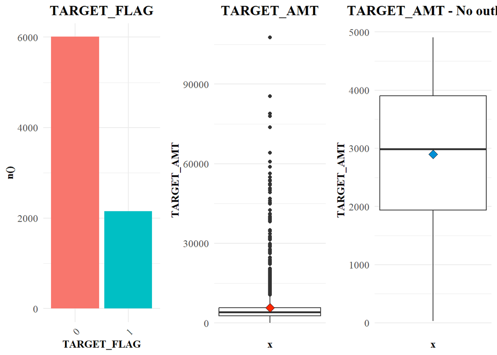

### **DISTRIBUTIONS**

As part of the data exploration I would like to find out the distribution, discrete and continuous variables. I will check the outliers and analyze the skewness of the variables. I will also look at the correlation between variables to see if they are multicollinearity among the independent variables.

#### **BAR CHART**

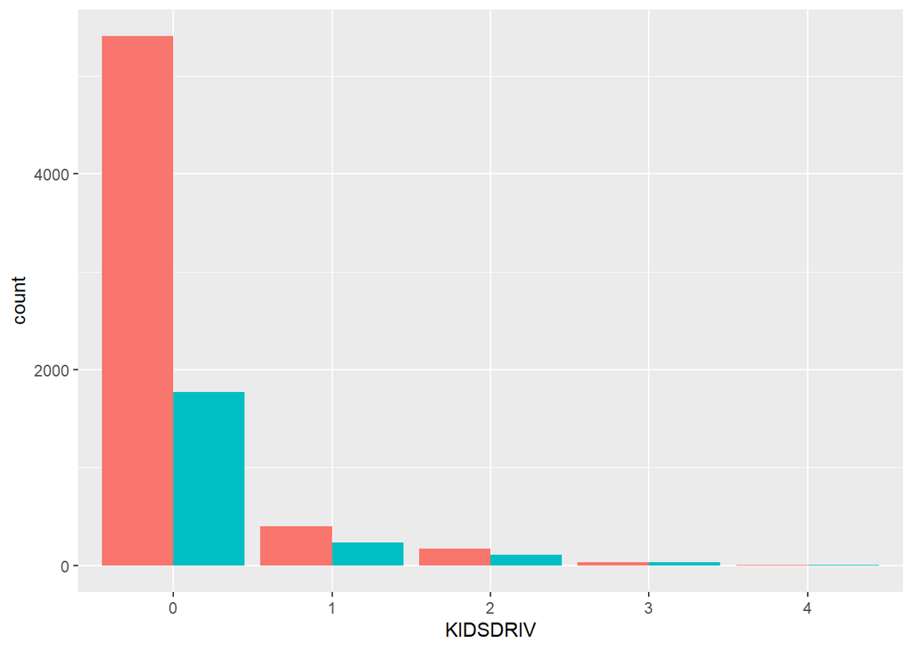

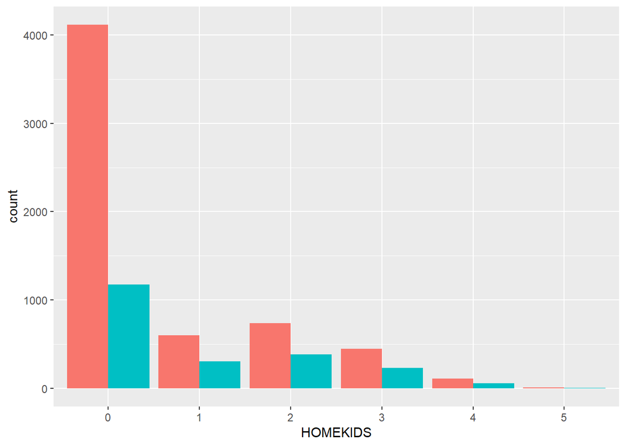

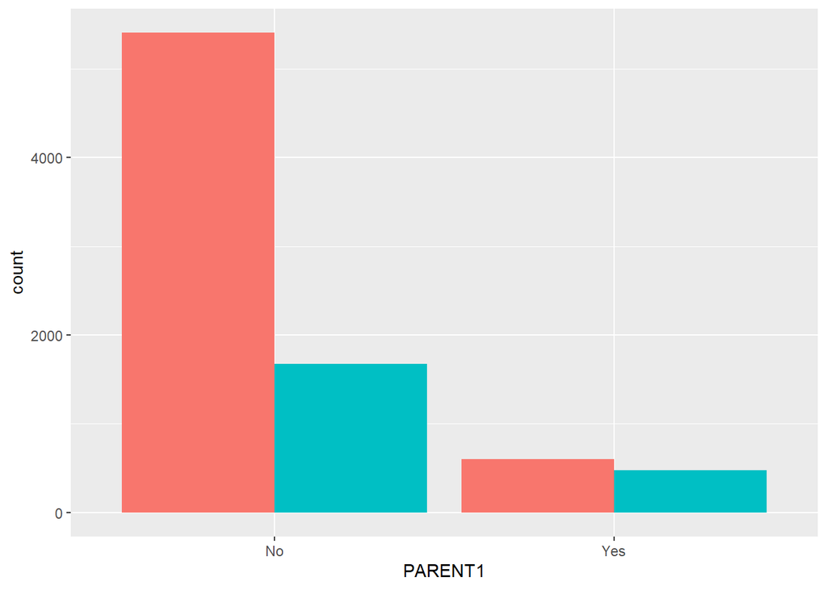

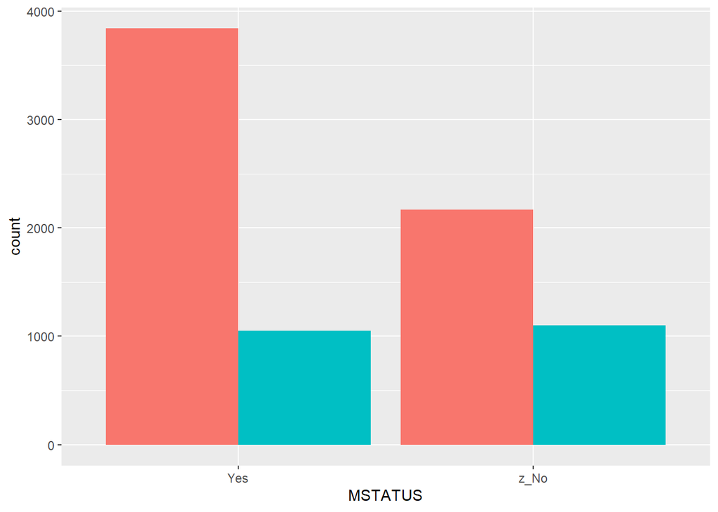

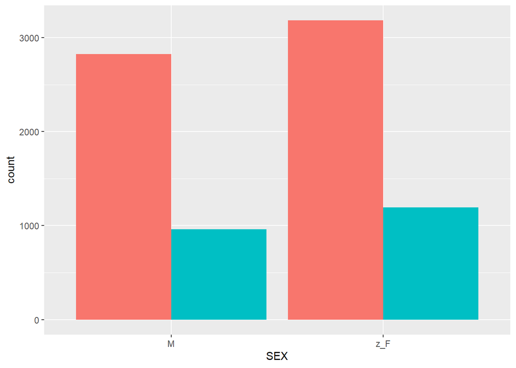

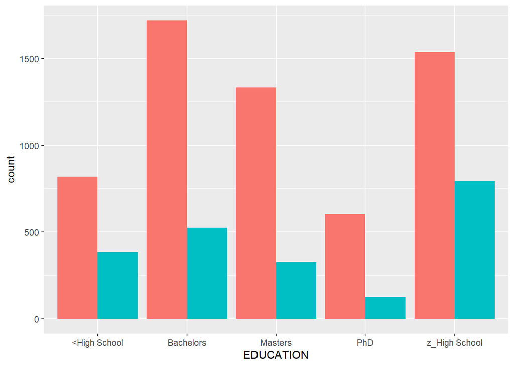

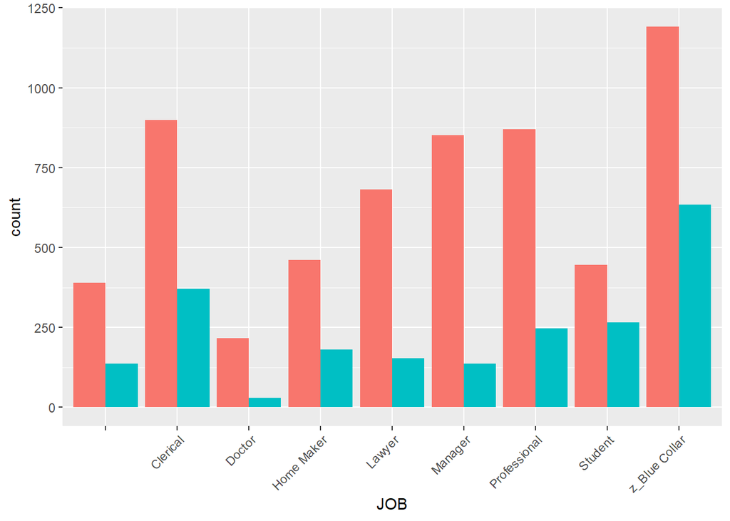

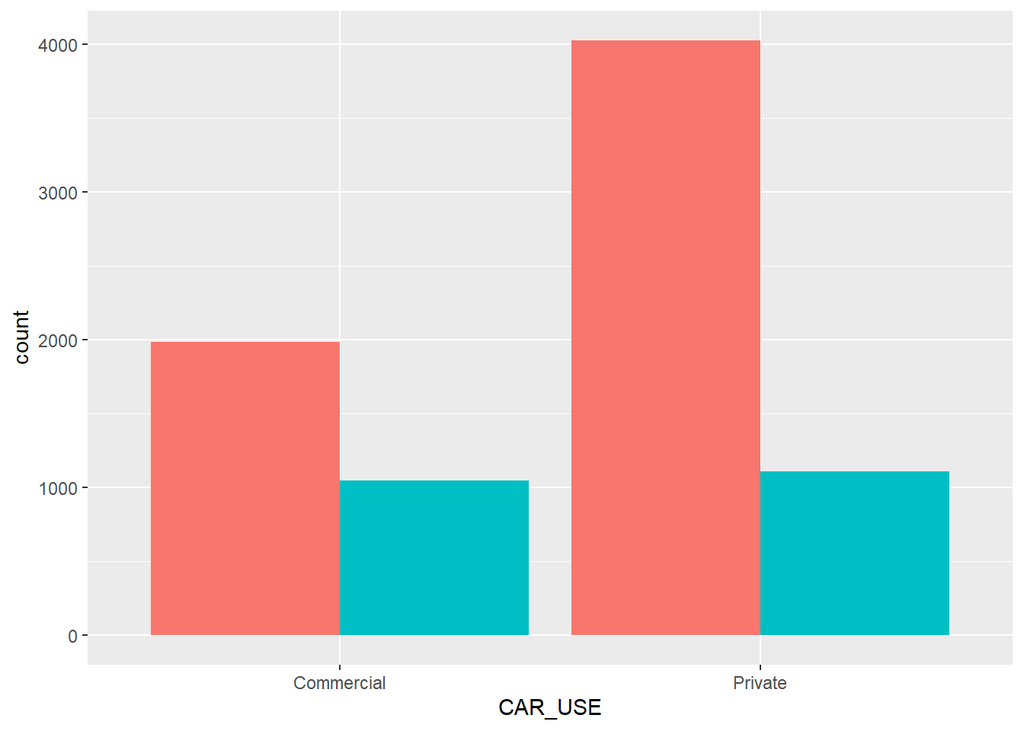

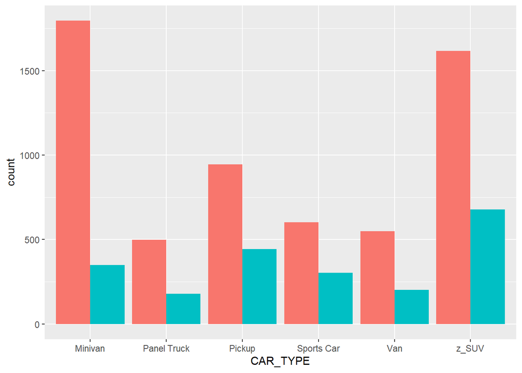

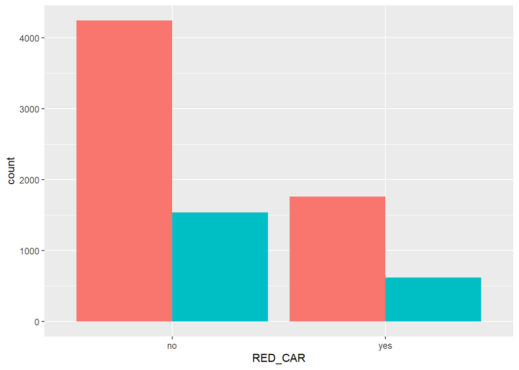

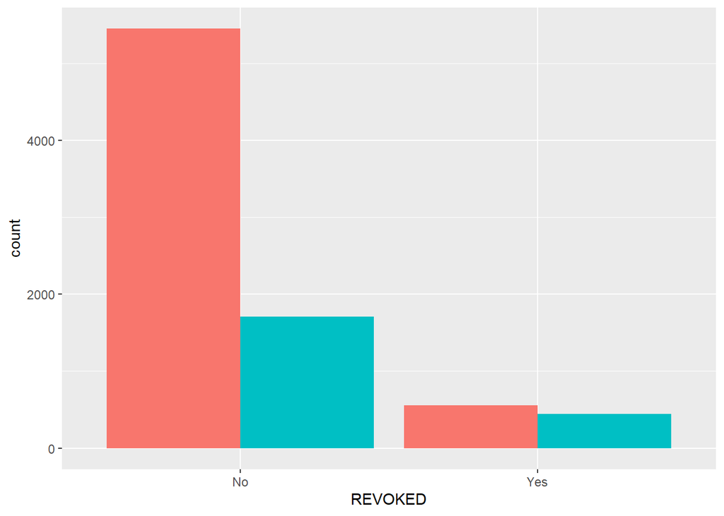

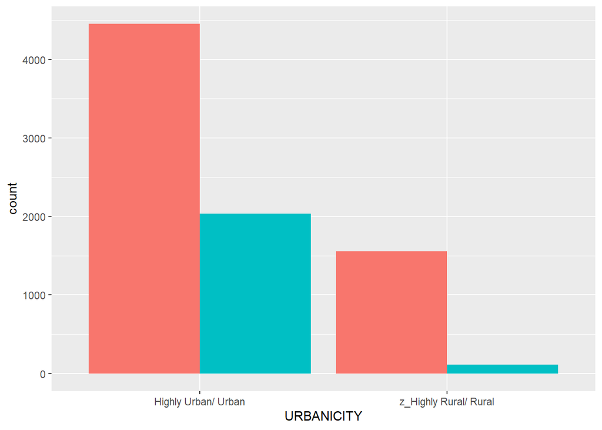

[1 more figures not shown]

Frequency counts of class occurrence for the discrete variables are provided below:

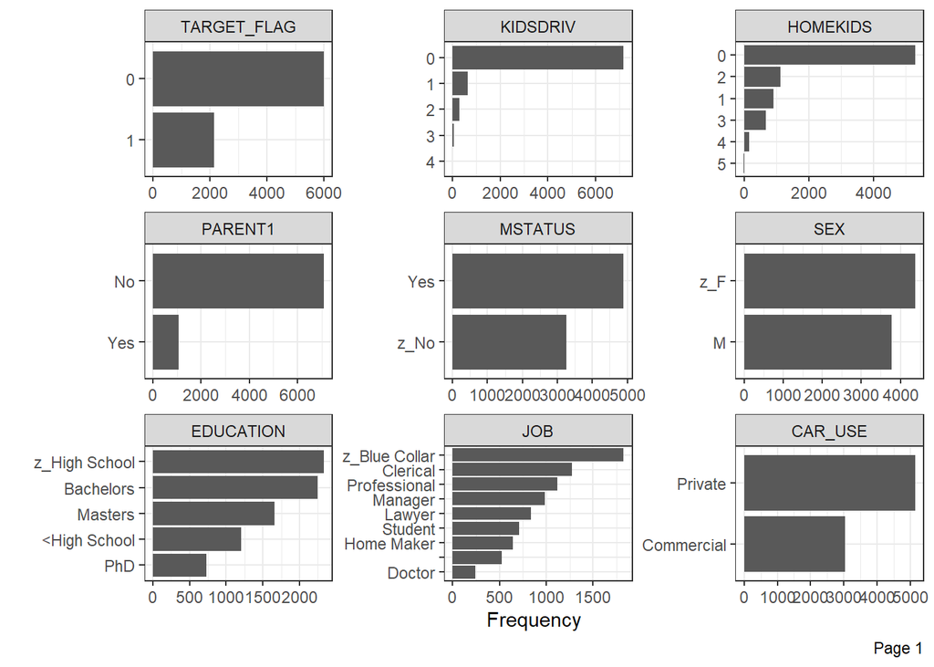

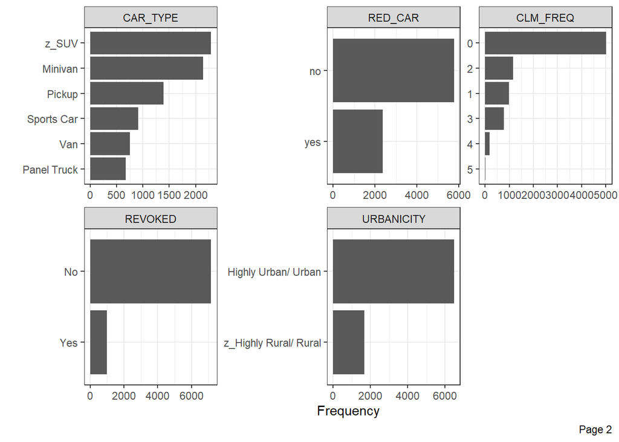

I visualize the distribution profiles for each of the predictor variables. This will help me make a plan on which variables to include, how they might be related to each other or the target, and finally identify outliers or transformations that might help improve model resolution.

#### **HISTORGRAM DISTRIBUTIONS**

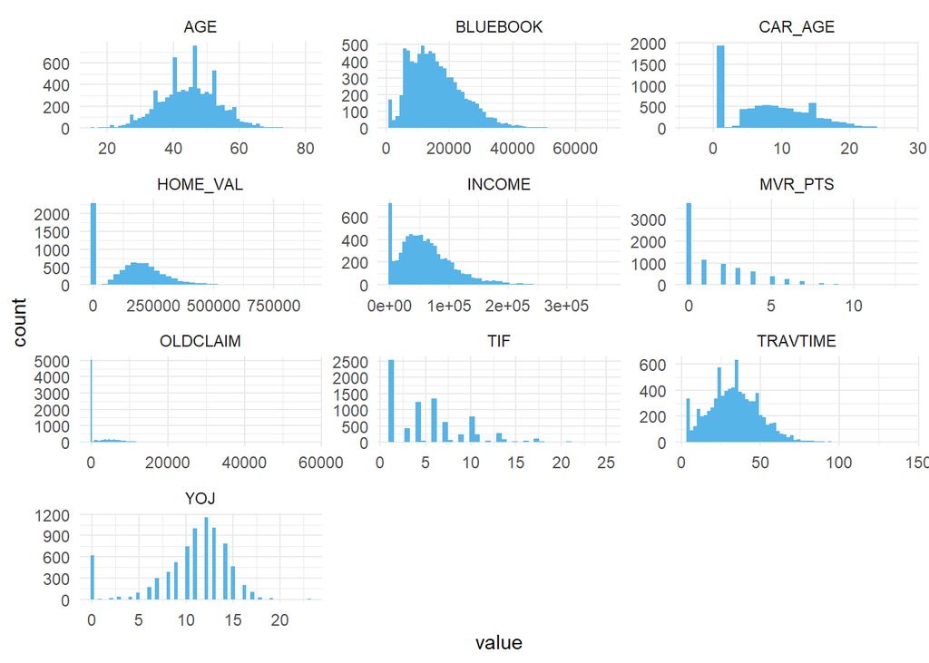

Several features have both a distribution along with a high number of values at an extreme. However, based on the feature meanings and provided information, there is no reason to believe that any of these extreme values are mistakes, data errors, or otherwise inexplicable. As such, we will not remove the extreme values, as they represent valuable data and could be predictive of the target.

##### **BOXPLOT**

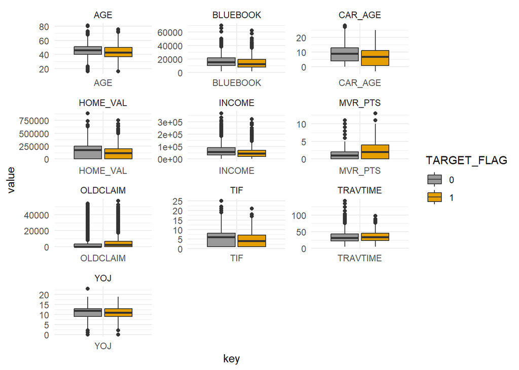

Here I see BLUEBOOK, INCOME, OLDCLAIM have high number of outliers compared to other variables. I also see people with older car, higher home value, higher income or older customer get in to less car crash. However, people with motor vehicle record points or high number of old claims tend to get in to more car crash.

#### **VARIABLE PLOTS**

##### **SCATTER PLOT**

A pairwise comparison plot between all features, both numeric and non-numeric is shown following the scatter plot where this initially implies that there aren’t a significant amount of correlated features and this can give some insight into the expected significance and performing dimensionality reduction on the datasets for the models.

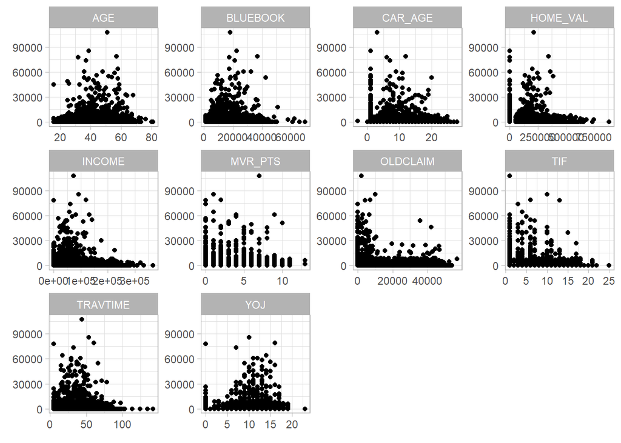

##### **CORRELATION TABLE**

|  | Correlation TARGET_FLAG | Correlation TARGET_AMT |
| --- | --- | --- |
| TARGET_FLAG | 1.0000000 | 1.0000000 |
| TARGET_AMT | 0.8334240 | 0.8334240 |
| MVR_PTS | 0.2191323 | 0.1970216 |
| CLM_FREQ | 0.2161961 | 0.1741927 |
| OLDCLAIM | 0.1947302 | 0.1611626 |
| PARENT1 | 0.1576222 | 0.1359305 |
| REVOKED | 0.1519391 | 0.1263285 |
| MSTATUS | 0.1351248 | 0.1214701 |
| HOMEKIDS | 0.1156210 | 0.1008356 |
| KIDSDRIV | 0.1036683 | 0.0877148 |
| CAR_TYPE | 0.1023650 | 0.0797487 |
| JOB | 0.0612262 | 0.0488313 |
| TRAVTIME | 0.0492559 | 0.0401971 |
| EDUCATION | 0.0428730 | 0.0397864 |
| SEX | 0.0210786 | 0.0088270 |
| RED_CAR | -0.0069473 | 0.0005877 |
| TIF | -0.0823431 | -0.0683183 |
| BLUEBOOK | -0.1092768 | -0.0709830 |
| CAR_USE | -0.1426737 | -0.1287263 |
| URBANICITY | -0.2242509 | -0.1904945 |

##### **CORRELATION PLOT**

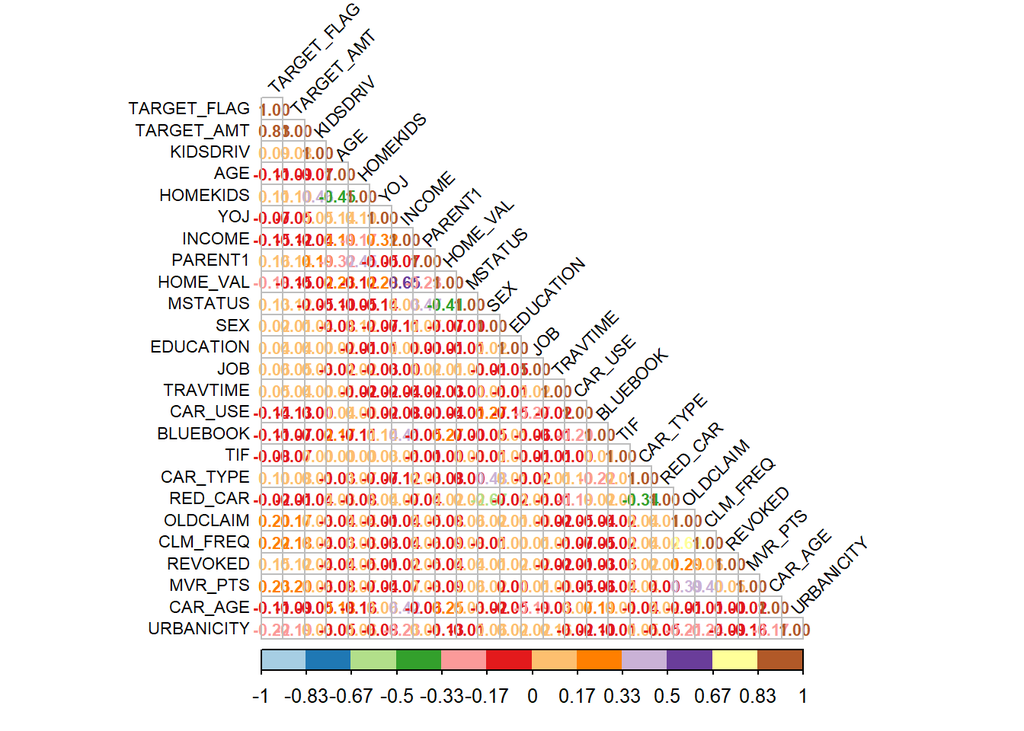

In the correlation table and plot we see MVR_PTS, CLM_FREQ, and OLDCLAIM are the most positively correlated variables with our response variables. Whereas, URBANICITY is the most negatively correlated variable. Rest of the variables are weakly correlated.

Distribution of Kids Driving, Kids being home, Single Parent, and maried families most of them are not in a car crash.

Distribution of Female, N/A Degrees, Blue Colar, SUV, and Highly Urban Area are are into more car crash.

## **DATA PREPARATION**

### **DATA CLEANING**

Data Observation from the EDA that will need to be addressed:

- TARGET_FLAG appears to have an imbalance with almost 3X as may no accidents vs accidents.
- TARGET_AMT has some outlier that we will have to address in data prep, model selection or both
- NAs in Explanatory Variables - Several variables have NA (YOJ, CAR_AGE, AGE)
- Dollar Signs ($) - Several variables have dollars that cause the variables to be treated as factors

I will use the tidyverse dplyr to address some of the data clean-up items so we can continue our EDA and extend it to the explanatory variables. We’ll make the following changes to the data set and then have another look at the data summaries.

- Remove character from number variable and cast as numeric (INCOME, HOME_VAL, BLUE_BOOK, OLDCLAIM)
- INCOME, HOME_VAL, BLUEBOOK and OLDCLAIM has also been rescaled by dividing by 1000
- Remove random characters from variables (z_, <, etc.)
- Replace NAs with median values
- Replace negative CAR_AGE value(s) with the Median CAR_AGE

I have already performed some data transformation for our visualization. INCOME, HOME_VAL, BLUEBOOK, OLDCLAIM variables have dollar sign and comma in them. These were removed (and converted as integer) using the stringr package. As you have seen in our statistical analysis, some of the variables have missing values. I will use the mice package and random forest method to impute the missing data. Mice uses multivariate imputations to estimate the missing values. Using multiple imputations helps in resolving the uncertainty for the missingness. Our response variables will be removed as predictor variables but still will be imputed. Lastly, we will perform the same data preparation for our unseen dataset.

### **REVISED DATA**

```
##              vars    n    mean      sd median trimmed    mad  min       max
## TARGET_FLAG*    1 8161    1.26    0.44   1.00    1.20   0.00  1.0      2.00
## TARGET_AMT      2 8161 1504.32 4704.03   0.00  593.71   0.00  0.0 107586.14
## KIDSDRIV*       3 8161    1.17    0.51   1.00    1.03   0.00  1.0      5.00
## AGE             4 8161   44.79    8.62  45.00   44.83   8.90 16.0     81.00
## HOMEKIDS*       5 8161    1.72    1.12   1.00    1.50   0.00  1.0      6.00
## YOJ             6 8161   10.53    3.98  11.00   11.08   2.97  0.0     23.00
## INCOME          7 8161   61.47   46.29  54.03   56.56  38.98  0.0    367.03
## PARENT1*        8 8161    1.13    0.34   1.00    1.04   0.00  1.0      2.00
## HOME_VAL        9 8161  155.23  125.41 161.16  145.06 131.53  0.0    885.28
## MSTATUS*       10 8161    1.60    0.49   2.00    1.62   0.00  1.0      2.00
## SEX*           11 8161    1.46    0.50   1.00    1.45   0.00  1.0      2.00
## EDUCATION*     12 8161    2.11    0.91   2.00    2.02   1.48  1.0      4.00
## JOB*           13 8161    4.83    2.62   5.00    4.76   4.45  1.0      9.00
## TRAVTIME       14 8161   33.49   15.91  33.00   33.00  16.31  5.0    142.00
## CAR_USE*       15 8161    1.63    0.48   2.00    1.66   0.00  1.0      2.00
## BLUEBOOK       16 8161   15.71    8.42  14.44   15.04   8.45  1.5     69.74
## TIF            17 8161    5.35    4.15   4.00    4.84   4.45  1.0     25.00
## CAR_TYPE*      18 8161    3.34    1.76   3.00    3.31   2.97  1.0      6.00
## RED_CAR*       19 8161    1.29    0.45   1.00    1.24   0.00  1.0      2.00
## OLDCLAIM       20 8161    4.04    8.78   0.00    1.72   0.00  0.0     57.04
## CLM_FREQ*      21 8161    1.80    1.16   1.00    1.59   0.00  1.0      6.00
## REVOKED*       22 8161    1.12    0.33   1.00    1.03   0.00  1.0      2.00
## MVR_PTS        23 8161    1.70    2.15   1.00    1.31   1.48  0.0     13.00
## CAR_AGE        24 8161    8.31    5.52   8.00    7.96   5.93  0.0     28.00
## URBANICITY*    25 8161    1.80    0.40   2.00    1.87   0.00  1.0      2.00
## target_amt*    26 8161  256.71  512.57   1.00  125.62   0.00  1.0   1949.00
## target*        27 8161    1.26    0.44   1.00    1.20   0.00  1.0      2.00
##                  range  skew kurtosis    se
## TARGET_FLAG*      1.00  1.07    -0.85  0.00
## TARGET_AMT   107586.14  8.71   112.29 52.07
## KIDSDRIV*         4.00  3.35    11.78  0.01
## AGE              65.00 -0.03    -0.06  0.10
## HOMEKIDS*         5.00  1.34     0.65  0.01
## YOJ              23.00 -1.26     1.45  0.04
## INCOME          367.03  1.24     2.45  0.51
## PARENT1*          1.00  2.17     2.73  0.00
## HOME_VAL        885.28  0.49     0.16  1.39
## MSTATUS*          1.00 -0.41    -1.83  0.01
## SEX*              1.00  0.14    -1.98  0.01
## EDUCATION*        3.00  0.50    -0.51  0.01
## JOB*              8.00  0.13    -1.46  0.03
## TRAVTIME        137.00  0.45     0.66  0.18
## CAR_USE*          1.00 -0.53    -1.72  0.01
## BLUEBOOK         68.24  0.79     0.79  0.09
## TIF              24.00  0.89     0.42  0.05
## CAR_TYPE*         5.00 -0.10    -1.43  0.02
## RED_CAR*          1.00  0.92    -1.16  0.01
## OLDCLAIM         57.04  3.12     9.86  0.10
## CLM_FREQ*         5.00  1.21     0.28  0.01
## REVOKED*          1.00  2.30     3.30  0.00
## MVR_PTS          13.00  1.35     1.38  0.02
## CAR_AGE          28.00  0.30    -0.60  0.06
## URBANICITY*       1.00 -1.46     0.15  0.00
## target_amt*    1948.00  1.90     2.25  5.67
## target*           1.00  1.07    -0.85  0.00
```

```
##  TARGET_FLAG   TARGET_AMT     KIDSDRIV      AGE        HOMEKIDS      YOJ
##  0:6008      Min.   :     0   0:7180   Min.   :16.00   0:5289   Min.   : 0.00
##  1:2153      1st Qu.:     0   1: 636   1st Qu.:39.00   1: 902   1st Qu.: 9.00
##              Median :     0   2: 279   Median :45.00   2:1118   Median :11.00
##              Mean   :  1504   3:  62   Mean   :44.79   3: 674   Mean   :10.53
##              3rd Qu.:  1036   4:   4   3rd Qu.:51.00   4: 164   3rd Qu.:13.00
##              Max.   :107586            Max.   :81.00   5:  14   Max.   :23.00
##
##      INCOME       PARENT1       HOME_VAL     MSTATUS    SEX
##  Min.   :  0.00   No :7084   Min.   :  0.0   No :3267   F:4375
##  1st Qu.: 29.71   Yes:1077   1st Qu.:  0.0   Yes:4894   M:3786
##  Median : 54.03              Median :161.2
##  Mean   : 61.47              Mean   :155.2
##  3rd Qu.: 83.30              3rd Qu.:233.4
##  Max.   :367.03              Max.   :885.3
##
##        EDUCATION              JOB          TRAVTIME        CAR_USE
##  Bachelors  :2242   Blue Collar :1825   Min.   :  5.00   Length:8161
##  High School:3533   Clerical    :1271   1st Qu.: 22.00   Class :character
##  Masters    :1658   Professional:1117   Median : 33.00   Mode  :character
##  PhD        : 728   Manager     : 988   Mean   : 33.49
##                     Lawyer      : 835   3rd Qu.: 44.00
##                     Student     : 712   Max.   :142.00
##                     (Other)     :1413
##     BLUEBOOK          TIF                CAR_TYPE      RED_CAR
##  Min.   : 1.50   Min.   : 1.000   Minivan    :2145   Length:8161
##  1st Qu.: 9.28   1st Qu.: 1.000   Panel Truck: 676   Class :character
##  Median :14.44   Median : 4.000   Pickup     :1389   Mode  :character
##  Mean   :15.71   Mean   : 5.351   Sports Car : 907
##  3rd Qu.:20.85   3rd Qu.: 7.000   SUV        :2294
##  Max.   :69.74   Max.   :25.000   Van        : 750
##
##     OLDCLAIM      CLM_FREQ   REVOKED             MVR_PTS          CAR_AGE
##  Min.   : 0.000   0:5009   Length:8161        Min.   : 0.000   Min.   : 0.000
##  1st Qu.: 0.000   1: 997   Class :character   1st Qu.: 0.000   1st Qu.: 4.000
##  Median : 0.000   2:1171   Mode  :character   Median : 1.000   Median : 8.000
##  Mean   : 4.037   3: 776                      Mean   : 1.696   Mean   : 8.309
##  3rd Qu.: 4.636   4: 190                      3rd Qu.: 3.000   3rd Qu.:12.000
##  Max.   :57.037   5:  18                      Max.   :13.000   Max.   :28.000
##
##                URBANICITY
##  Highly Rural/ Rural:1669
##  Highly Urban/ Urban:6492
##
##
##
##
##
```

```
## 'data.frame':    8161 obs. of  25 variables:
##  $ TARGET_FLAG: Factor w/ 2 levels "0","1": 1 1 1 1 1 2 1 2 2 1 ...
##  $ TARGET_AMT : num  0 0 0 0 0 ...
##  $ KIDSDRIV   : Factor w/ 5 levels "0","1","2","3",..: 1 1 1 1 1 1 1 2 1 1 ...
##  $ AGE        : int  60 43 35 51 50 34 54 37 34 50 ...
##  $ HOMEKIDS   : Factor w/ 6 levels "0","1","2","3",..: 1 1 2 1 1 2 1 3 1 1 ...
##  $ YOJ        : int  11 11 10 14 11 12 11 11 10 7 ...
##  $ INCOME     : num  67.3 91.4 16 54 115 ...
##  $ PARENT1    : Factor w/ 2 levels "No","Yes": 1 1 1 1 1 2 1 1 1 1 ...
##  $ HOME_VAL   : num  0 257 124 306 244 ...
##  $ MSTATUS    : Factor w/ 2 levels "No","Yes": 1 1 2 2 2 1 2 2 1 1 ...
##  $ SEX        : Factor w/ 2 levels "F","M": 2 2 1 2 1 1 1 2 1 2 ...
##  $ EDUCATION  : Factor w/ 4 levels "Bachelors","High School",..: 4 2 2 2 4 1 2 1 1 1 ...
##  $ JOB        : Factor w/ 9 levels "","Blue Collar",..: 8 2 3 2 4 2 2 2 3 8 ...
##  $ TRAVTIME   : int  14 22 5 32 36 46 33 44 34 48 ...
##  $ CAR_USE    : chr  "Private" "Commercial" "Private" "Private" ...
##  $ BLUEBOOK   : num  14.23 14.94 4.01 15.44 18 ...
##  $ TIF        : int  11 1 4 7 1 1 1 1 1 7 ...
##  $ CAR_TYPE   : Factor w/ 6 levels "Minivan","Panel Truck",..: 1 1 5 1 5 4 5 6 5 6 ...
##  $ RED_CAR    : chr  "yes" "yes" "no" "yes" ...
##  $ OLDCLAIM   : num  4.46 0 38.69 0 19.22 ...
##  $ CLM_FREQ   : Factor w/ 6 levels "0","1","2","3",..: 3 1 3 1 3 1 1 2 1 1 ...
##  $ REVOKED    : chr  "No" "No" "No" "No" ...
##  $ MVR_PTS    : int  3 0 3 0 3 0 0 10 0 1 ...
##  $ CAR_AGE    : int  18 1 10 6 17 7 1 7 1 17 ...
##  $ URBANICITY : Factor w/ 2 levels "Highly Rural/ Rural",..: 2 2 2 2 2 2 2 2 2 1 ...
```

```
## [1] 0
```

### **IMPUTATING TRAIN DATA**

[output not shown]

[output not shown]

```
## [1] "Missing value after imputation: 0"
```

### **PREPARING EVALUATION DATA**

### **IMPUTING EVALUATION DATA**

```
## [1] "Missing value after imputation: 0"
```

### **CHECK FOR MULTICOLLINEARITY**

|  | VIF Score |
| --- | --- |
| TARGET_AMT | 1.184684 |
| KIDSDRIV | 1.322832 |
| AGE | 1.419119 |
| HOMEKIDS | 2.068537 |
| YOJ | 1.245800 |
| INCOME | 2.386653 |
| PARENT1 | 1.847939 |
| HOME_VAL | 2.211490 |
| MSTATUS | 1.898765 |
| SEX | 2.086272 |
| EDUCATION | 1.272411 |
| JOB | 1.221759 |
| TRAVTIME | 1.039295 |
| CAR_USE | 1.362761 |
| BLUEBOOK | 1.304307 |
| TIF | 1.009049 |
| CAR_TYPE | 1.203893 |
| RED_CAR | 1.809656 |
| OLDCLAIM | 2.200755 |
| CLM_FREQ | 2.130649 |
| REVOKED | 1.148421 |
| MVR_PTS | 1.249469 |
| CAR_AGE | 1.373371 |
| URBANICITY | 1.249199 |

In the table above table I check for multicollinearity and there is no cause for concern because the VIF score is at a conservative level for all variables.

## **BUILD MODELS**

I will build at least three different multiple linear regression models and three different binary logistic regression models using the original dataset, the imputed dataset, forward and backward selected variables and a boxcox transformed dataset to see which one yields the best performance.

### **MULTIPLE LINEAR REGRESSION MODEL 1**

#### **ORIGIONAL VALUE MODEL**

```
##
## Call:
## lm(formula = TARGET_AMT ~ ., data = insurance_corr)
##
## Residuals:
##     Min      1Q  Median      3Q     Max
## -898.90 -286.25 -134.43   62.85 1927.07
##
## Coefficients:
##               Estimate Std. Error t value Pr(>|t|)
## (Intercept)  4.018e+02  7.820e+01   5.138 2.86e-07 ***
## KIDSDRIV     4.205e+01  1.318e+01   3.189  0.00143 **
## AGE         -2.046e-01  8.070e-01  -0.254  0.79986
## HOMEKIDS     1.359e+01  7.532e+00   1.804  0.07121 .
## YOJ         -3.491e-01  1.590e+00  -0.220  0.82625
## INCOME      -2.270e-02  4.803e-03  -4.727 2.33e-06 ***
## PARENT1      7.414e+01  2.336e+01   3.173  0.00151 **
## HOME_VAL    -1.082e-02  5.505e-03  -1.965  0.04946 *
## MSTATUS      7.301e+01  1.685e+01   4.332 1.50e-05 ***
## SEX         -9.673e+00  1.756e+01  -0.551  0.58178
## EDUCATION    6.679e+00  4.132e+00   1.616  0.10606
## JOB         -6.667e-01  2.347e+00  -0.284  0.77637
## TRAVTIME     2.185e+00  3.772e-01   5.793 7.25e-09 ***
## CAR_USE     -1.472e+02  1.392e+01 -10.571  < 2e-16 ***
## BLUEBOOK    -2.513e-02  9.504e-03  -2.644  0.00821 **
## TIF         -7.286e+00  1.416e+00  -5.147 2.73e-07 ***
## CAR_TYPE     1.877e+01  3.517e+00   5.335 9.87e-08 ***
## RED_CAR     -1.768e+01  1.732e+01  -1.021  0.30740
## OLDCLAIM    -4.355e-03  1.039e-02  -0.419  0.67518
## CLM_FREQ     2.315e+01  7.358e+00   3.147  0.00166 **
## REVOKED      1.281e+02  1.915e+01   6.693 2.37e-11 ***
## MVR_PTS      2.597e+01  3.034e+00   8.560  < 2e-16 ***
## CAR_AGE     -3.795e+00  1.182e+00  -3.210  0.00133 **
## URBANICITY  -2.685e+02  1.590e+01 -16.891  < 2e-16 ***
## ---
## Signif. codes:  0 '***' 0.001 '**' 0.01 '*' 0.05 '.' 0.1 ' ' 1
##
## Residual standard error: 470.1 on 6424 degrees of freedom
##   (1713 observations deleted due to missingness)
## Multiple R-squared:  0.1564, Adjusted R-squared:  0.1534
## F-statistic: 51.79 on 23 and 6424 DF,  p-value: < 2.2e-16
```

In the Mutiple Linear Regression Model 1, I see the min-max and 1Q-3Q have different magnitudes and the median is not close to zero. This means is not good but lets do some more evaluation. The p-value below shows that the probability of this variables to be irrelevant is very low. Lastly, R-squared is 0.15, which means this model explains 15% of the data’s variation. Overall, I would say this is a bad model.

### **MULTIPLE LINEAR REGRESSION MODEL 2**

#### **IMPUTED MODEL**

```
##
## Call:
## lm(formula = TARGET_AMT ~ ., data = insurance_vif)
##
## Residuals:
##     Min      1Q  Median      3Q     Max
## -941.11 -287.36 -134.41   63.49 1941.29
##
## Coefficients:
##               Estimate Std. Error t value Pr(>|t|)
## (Intercept) -1.774e+02  6.767e+01  -2.622 0.008769 **
## KIDSDRIV     5.544e+01  1.172e+01   4.730 2.29e-06 ***
## AGE          1.712e-01  7.219e-01   0.237 0.812544
## HOMEKIDS     1.399e+01  6.724e+00   2.080 0.037525 *
## YOJ         -1.349e+00  1.465e+00  -0.920 0.357368
## INCOME      -2.577e-02  4.071e-03  -6.329 2.59e-10 ***
## PARENT1      6.999e+01  2.095e+01   3.341 0.000840 ***
## HOME_VAL    -1.096e-02  4.707e-03  -2.329 0.019899 *
## MSTATUS     -8.202e+01  1.465e+01  -5.598 2.25e-08 ***
## SEX         -7.897e+00  1.512e+01  -0.522 0.601452
## EDUCATION    9.800e+00  6.489e+00   1.510 0.131003
## JOB         -5.901e+00  2.198e+00  -2.684 0.007283 **
## TRAVTIME     2.077e+00  3.356e-01   6.188 6.41e-10 ***
## CAR_USE     -1.386e+02  1.252e+01 -11.067  < 2e-16 ***
## BLUEBOOK    -2.996e-02  8.271e-03  -3.622 0.000294 ***
## TIF         -7.601e+00  1.263e+00  -6.020 1.81e-09 ***
## CAR_TYPE     1.735e+01  3.258e+00   5.327 1.03e-07 ***
## RED_CAR     -2.852e+00  1.545e+01  -0.185 0.853615
## OLDCLAIM    -7.666e-03  9.183e-03  -0.835 0.403847
## CLM_FREQ     2.174e+01  6.574e+00   3.308 0.000945 ***
## REVOKED      1.318e+02  1.700e+01   7.754 9.96e-15 ***
## MVR_PTS      2.577e+01  2.704e+00   9.530  < 2e-16 ***
## CAR_AGE     -3.332e+00  1.108e+00  -3.008 0.002642 **
## URBANICITY   2.718e+02  1.415e+01  19.210  < 2e-16 ***
## ---
## Signif. codes:  0 '***' 0.001 '**' 0.01 '*' 0.05 '.' 0.1 ' ' 1
##
## Residual standard error: 471.6 on 8137 degrees of freedom
## Multiple R-squared:  0.1559, Adjusted R-squared:  0.1535
## F-statistic: 65.34 on 23 and 8137 DF,  p-value: < 2.2e-16
```

In the Multiple Linear Regression Model 2, I see the min-max and 1Q-3Q have different magnitudes and the median is not close to zero. This means is not good but lets do some more evaluation. The p-value below shows that the probability of this variables to be irrelevant is very low. Lastly, R-squared is 0.15, which means this model explains 15% of the data’s variation. Overall, I would say this is a bad model.

### **MULTIPLE LINEAR REGRESSION MODEL 3**

#### **STEPWISE TRANSFORMED MODEL**

```
##
## Call:
## lm(formula = TARGET_AMT ~ KIDSDRIV + HOMEKIDS + INCOME + PARENT1 +
##     HOME_VAL + MSTATUS + EDUCATION + JOB + TRAVTIME + CAR_USE +
##     BLUEBOOK + TIF + CAR_TYPE + CLM_FREQ + REVOKED + MVR_PTS +
##     CAR_AGE + URBANICITY, data = insurance_vif)
##
## Residuals:
##     Min      1Q  Median      3Q     Max
## -946.43 -287.59 -134.29   62.75 1937.87
##
## Coefficients:
##               Estimate Std. Error t value Pr(>|t|)
## (Intercept) -1.981e+02  5.638e+01  -3.513 0.000446 ***
## KIDSDRIV     5.621e+01  1.155e+01   4.866 1.16e-06 ***
## HOMEKIDS     1.296e+01  6.167e+00   2.102 0.035621 *
## INCOME      -2.674e-02  3.964e-03  -6.745 1.64e-11 ***
## PARENT1      7.052e+01  2.085e+01   3.383 0.000721 ***
## HOME_VAL    -1.100e-02  4.685e-03  -2.347 0.018934 *
## MSTATUS     -8.304e+01  1.459e+01  -5.693 1.29e-08 ***
## EDUCATION    1.014e+01  6.443e+00   1.573 0.115725
## JOB         -5.541e+00  2.151e+00  -2.575 0.010027 *
## TRAVTIME     2.083e+00  3.355e-01   6.208 5.62e-10 ***
## CAR_USE     -1.364e+02  1.192e+01 -11.449  < 2e-16 ***
## BLUEBOOK    -2.942e-02  8.188e-03  -3.593 0.000328 ***
## TIF         -7.629e+00  1.262e+00  -6.045 1.56e-09 ***
## CAR_TYPE     1.844e+01  3.018e+00   6.111 1.04e-09 ***
## CLM_FREQ     1.825e+01  5.057e+00   3.609 0.000309 ***
## REVOKED      1.270e+02  1.606e+01   7.908 2.97e-15 ***
## MVR_PTS      2.549e+01  2.674e+00   9.533  < 2e-16 ***
## CAR_AGE     -3.269e+00  1.106e+00  -2.956 0.003124 **
## URBANICITY   2.704e+02  1.412e+01  19.154  < 2e-16 ***
## ---
## Signif. codes:  0 '***' 0.001 '**' 0.01 '*' 0.05 '.' 0.1 ' ' 1
##
## Residual standard error: 471.5 on 8142 degrees of freedom
## Multiple R-squared:  0.1556, Adjusted R-squared:  0.1538
## F-statistic: 83.38 on 18 and 8142 DF,  p-value: < 2.2e-16
```

In the Multiple Linear Regression Model 3, I see the min-max and 1Q-3Q have different magnitudes and the median is not close to zero. This means is not good but lets do some more evaluation. The p-value below shows that the probability of this variables to be irrelevant is very low. Lastly, R-squared is 0.15, which means this model explains 15% of the data’s variation. However, we see improved p-value for several variables. Overall, I would say this is a better model.

### **MULTIPLE LINEAR REGRESSION MODEL 4**

#### **BOXCOX TRANSFORMATION MODEL**

```
##
## Call:
## lm(formula = TARGET_AMT ~ ., data = in_bc_transformed)
##
## Residuals:
##     Min      1Q  Median      3Q     Max
## -1.6916 -0.5487 -0.2213  0.5943  2.4000
##
## Coefficients:
##               Estimate Std. Error t value Pr(>|t|)
## (Intercept)  3.762e-02  1.060e-01   0.355 0.722752
## KIDSDRIV     4.266e-01  7.438e-02   5.736 1.01e-08 ***
## AGE         -1.301e-04  1.185e-03  -0.110 0.912633
## HOMEKIDS     1.118e-01  6.014e-02   1.859 0.063008 .
## YOJ          3.976e-05  6.475e-04   0.061 0.951035
## INCOME      -2.029e-03  2.538e-04  -7.994 1.48e-15 ***
## PARENT1      1.257e-01  3.546e-02   3.546 0.000394 ***
## HOME_VAL    -3.491e-03  7.805e-04  -4.473 7.82e-06 ***
## MSTATUS     -1.246e-01  2.476e-02  -5.033 4.92e-07 ***
## SEX         -2.145e-02  2.406e-02  -0.892 0.372657
## EDUCATION    9.372e-04  1.627e-02   0.058 0.954075
## JOB         -3.417e-02  7.455e-03  -4.584 4.64e-06 ***
## TRAVTIME     1.111e-02  1.398e-03   7.944 2.22e-15 ***
## CAR_USE     -2.455e-01  2.013e-02 -12.197  < 2e-16 ***
## BLUEBOOK    -1.425e-03  2.026e-04  -7.032 2.20e-12 ***
## TIF         -5.322e-02  6.840e-03  -7.781 8.10e-15 ***
## CAR_TYPE     4.849e-02  7.110e-03   6.820 9.77e-12 ***
## RED_CAR     -8.095e-03  2.451e-02  -0.330 0.741221
## OLDCLAIM    -6.492e-03  1.048e-02  -0.619 0.535841
## CLM_FREQ     3.692e-01  1.401e-01   2.635 0.008430 **
## REVOKED      2.567e-01  2.598e-02   9.882  < 2e-16 ***
## MVR_PTS      1.313e-01  1.839e-02   7.136 1.05e-12 ***
## CAR_AGE     -1.588e-02  3.895e-03  -4.077 4.61e-05 ***
## URBANICITY   5.220e-01  2.256e-02  23.141  < 2e-16 ***
## ---
## Signif. codes:  0 '***' 0.001 '**' 0.01 '*' 0.05 '.' 0.1 ' ' 1
##
## Residual standard error: 0.7479 on 8137 degrees of freedom
## Multiple R-squared:  0.2171, Adjusted R-squared:  0.2149
## F-statistic: 98.12 on 23 and 8137 DF,  p-value: < 2.2e-16
```

As seen previously, most of our dataset has many skewed variables. When an attribute has a normal distribution but is shifted, this is called a skew. The distribution of an attribute can be shifted to reduce the skew and make it more normal The Box Cox transform can perform this operation (assumes all values are positive). In the Mutiple Linear Regression Model 4, I see the min-max and 1Q-3Q have quite similar magnitudes and the median is close to zero. This means this model is good but lets do some more evaluation. The p-value below shows that the probability of this variables to be irrelevant is very low. Lastly, R-squared is 0.22, which means this model explains 22% of the data’s variation. Overall, I would say this is the best model.

### **BINARY LOGISTIC REGRESSION MODEL 1**

#### **ORIGIONAL VALUE MODEL**

```
##
## Call:
## glm(formula = TARGET_FLAG ~ ., family = "binomial", data = logit_data)
##
## Deviance Residuals:
##     Min       1Q   Median       3Q      Max
## -2.5511  -0.7241  -0.4153   0.6582   3.1496
##
## Coefficients:
##               Estimate Std. Error z value Pr(>|z|)
## (Intercept) -4.699e+00  3.997e-01 -11.757  < 2e-16 ***
## KIDSDRIV     3.727e-01  6.038e-02   6.173 6.69e-10 ***
## AGE         -1.576e-03  3.922e-03  -0.402 0.687849
## HOMEKIDS     6.126e-02  3.652e-02   1.678 0.093428 .
## YOJ         -1.039e-02  7.895e-03  -1.316 0.188284
## INCOME      -1.500e-04  2.196e-05  -6.828 8.59e-12 ***
## PARENT1      3.782e-01  1.085e-01   3.486 0.000490 ***
## HOME_VAL    -9.970e-05  2.587e-05  -3.855 0.000116 ***
## MSTATUS     -4.882e-01  8.073e-02  -6.048 1.47e-09 ***
## SEX         -8.722e-02  8.405e-02  -1.038 0.299392
## EDUCATION    2.193e-02  3.662e-02   0.599 0.549298
## JOB         -4.472e-02  1.182e-02  -3.782 0.000155 ***
## TRAVTIME     1.529e-02  1.877e-03   8.147 3.75e-16 ***
## CAR_USE     -8.630e-01  6.751e-02 -12.783  < 2e-16 ***
## BLUEBOOK    -3.089e-04  4.579e-05  -6.745 1.53e-11 ***
## TIF         -5.479e-02  7.280e-03  -7.526 5.22e-14 ***
## CAR_TYPE     1.258e-01  1.833e-02   6.861 6.83e-12 ***
## RED_CAR     -2.167e-02  8.562e-02  -0.253 0.800234
## OLDCLAIM    -4.809e-05  4.504e-05  -1.068 0.285691
## CLM_FREQ     1.726e-01  3.212e-02   5.374 7.71e-08 ***
## REVOKED      7.732e-01  8.459e-02   9.141  < 2e-16 ***
## MVR_PTS      1.148e-01  1.360e-02   8.439  < 2e-16 ***
## CAR_AGE     -2.030e-02  6.128e-03  -3.313 0.000925 ***
## URBANICITY   2.303e+00  1.120e-01  20.559  < 2e-16 ***
## ---
## Signif. codes:  0 '***' 0.001 '**' 0.01 '*' 0.05 '.' 0.1 ' ' 1
##
## (Dispersion parameter for binomial family taken to be 1)
##
##     Null deviance: 9418.0  on 8160  degrees of freedom
## Residual deviance: 7410.5  on 8137  degrees of freedom
## AIC: 7458.5
##
## Number of Fisher Scoring iterations: 5
```

In the Binary Logistic Regression Model 1, I see min-max and 1Q-3Q magnitudes is quite close and the median is close to zero. This model shows many variables with significant p-value. We will see with following model whether AIC score improves or not.

### **BINARY LOGISTIC REGRESSION MODEL 2**

#### **STEPWISE TRANSFORMED MODEL**

```
##
## Call:
## glm(formula = TARGET_FLAG ~ KIDSDRIV + HOMEKIDS + YOJ + INCOME +
##     PARENT1 + HOME_VAL + MSTATUS + SEX + JOB + TRAVTIME + CAR_USE +
##     BLUEBOOK + TIF + CAR_TYPE + CLM_FREQ + REVOKED + MVR_PTS +
##     CAR_AGE + URBANICITY, family = "binomial", data = logit_data)
##
## Deviance Residuals:
##     Min       1Q   Median       3Q      Max
## -2.5589  -0.7269  -0.4152   0.6583   3.1335
##
## Coefficients:
##               Estimate Std. Error z value Pr(>|z|)
## (Intercept) -4.668e+00  3.764e-01 -12.400  < 2e-16 ***
## KIDSDRIV     3.701e-01  5.937e-02   6.234 4.53e-10 ***
## HOMEKIDS     6.653e-02  3.385e-02   1.965 0.049375 *
## YOJ         -1.129e-02  7.791e-03  -1.449 0.147446
## INCOME      -1.480e-04  2.185e-05  -6.775 1.24e-11 ***
## PARENT1      3.797e-01  1.078e-01   3.523 0.000427 ***
## HOME_VAL    -1.007e-04  2.577e-05  -3.906 9.37e-05 ***
## MSTATUS     -4.880e-01  8.072e-02  -6.045 1.50e-09 ***
## SEX         -9.714e-02  6.582e-02  -1.476 0.139999
## JOB         -4.634e-02  1.158e-02  -4.002 6.27e-05 ***
## TRAVTIME     1.528e-02  1.874e-03   8.149 3.66e-16 ***
## CAR_USE     -8.573e-01  6.639e-02 -12.912  < 2e-16 ***
## BLUEBOOK    -3.086e-04  4.549e-05  -6.783 1.18e-11 ***
## TIF         -5.467e-02  7.277e-03  -7.514 5.75e-14 ***
## CAR_TYPE     1.258e-01  1.831e-02   6.873 6.29e-12 ***
## CLM_FREQ     1.508e-01  2.524e-02   5.976 2.29e-09 ***
## REVOKED      7.424e-01  7.941e-02   9.349  < 2e-16 ***
## MVR_PTS      1.128e-01  1.344e-02   8.394  < 2e-16 ***
## CAR_AGE     -1.939e-02  5.857e-03  -3.311 0.000931 ***
## URBANICITY   2.300e+00  1.119e-01  20.559  < 2e-16 ***
## ---
## Signif. codes:  0 '***' 0.001 '**' 0.01 '*' 0.05 '.' 0.1 ' ' 1
##
## (Dispersion parameter for binomial family taken to be 1)
##
##     Null deviance: 9418.0  on 8160  degrees of freedom
## Residual deviance: 7412.2  on 8141  degrees of freedom
## AIC: 7452.2
##
## Number of Fisher Scoring iterations: 5
```

### **BINARY LOGISTIC REGRESSION MODEL 3**

#### **BOXCOX TRANSFORMATION MODEL**

```
##
## Call:
## glm(formula = TARGET_FLAG ~ ., family = "binomial", data = in_bc_transformed1)
##
## Deviance Residuals:
##     Min       1Q   Median       3Q      Max
## -2.3454  -0.7237  -0.4124   0.6818   3.1789
##
## Coefficients:
##               Estimate Std. Error z value Pr(>|z|)
## (Intercept) -3.6009127  0.3952562  -9.110  < 2e-16 ***
## KIDSDRIV     1.4193372  0.2442782   5.810 6.23e-09 ***
## AGE         -0.0000731  0.0040699  -0.018  0.98567
## HOMEKIDS     0.4598914  0.2131450   2.158  0.03096 *
## YOJ          0.0008458  0.0022402   0.378  0.70576
## INCOME      -0.0070773  0.0008628  -8.203 2.34e-16 ***
## PARENT1      0.2749391  0.1184098   2.322  0.02024 *
## HOME_VAL    -0.0111796  0.0026142  -4.276 1.90e-05 ***
## MSTATUS     -0.4986337  0.0873096  -5.711 1.12e-08 ***
## SEX         -0.0572990  0.0844166  -0.679  0.49729
## EDUCATION    0.0130390  0.0579210   0.225  0.82189
## JOB         -0.1209328  0.0253508  -4.770 1.84e-06 ***
## TRAVTIME     0.0418352  0.0049965   8.373  < 2e-16 ***
## CAR_USE     -0.8205034  0.0684799 -11.982  < 2e-16 ***
## BLUEBOOK    -0.0051373  0.0006966  -7.375 1.64e-13 ***
## TIF         -0.1835924  0.0238566  -7.696 1.41e-14 ***
## CAR_TYPE     0.1861866  0.0255297   7.293 3.03e-13 ***
## RED_CAR     -0.0233619  0.0856130  -0.273  0.78495
## OLDCLAIM    -0.0205915  0.0317499  -0.649  0.51663
## CLM_FREQ     1.1442057  0.4239340   2.699  0.00695 **
## REVOKED      0.7523221  0.0812796   9.256  < 2e-16 ***
## MVR_PTS      0.4082961  0.0622336   6.561 5.36e-11 ***
## CAR_AGE     -0.0535200  0.0133784  -4.000 6.32e-05 ***
## URBANICITY   2.2835945  0.1123839  20.320  < 2e-16 ***
## ---
## Signif. codes:  0 '***' 0.001 '**' 0.01 '*' 0.05 '.' 0.1 ' ' 1
##
## (Dispersion parameter for binomial family taken to be 1)
##
##     Null deviance: 9418.0  on 8160  degrees of freedom
## Residual deviance: 7391.9  on 8137  degrees of freedom
## AIC: 7439.9
##
## Number of Fisher Scoring iterations: 5
```

In the Binary Logistic Regression Model 3, I see min-max and 1Q-3Q magnitudes is quite close and the median is close to zero. This model too shows many variables with significant p-value. However, this model has the best AIC score so far.

## **SELECT MODEL**

### **BINARY LOGISTIC REGRESSION METRICS**

#### **COMPARING ALL BINARY LOGISTIC MODELS USING VARIOUS MEASURES**

|  | Model 5 | Model 6 | Model 7 |
| --- | --- | --- | --- |
| Accuracy | 0.7850754 | 0.7831148 | 0.7848303 |
| Class. Error Rate | 0.2149246 | 0.2168852 | 0.2151697 |
| Sensitivity | 0.3985137 | 0.3938690 | 0.3985137 |
| Specificity | 0.9236019 | 0.9226032 | 0.9232690 |
| Precision | 0.6514806 | 0.6458492 | 0.6504928 |
| F1 | 0.4945245 | 0.4893249 | 0.4942396 |
| AUC | 0.8059414 | 0.8058432 | 0.5700761 |

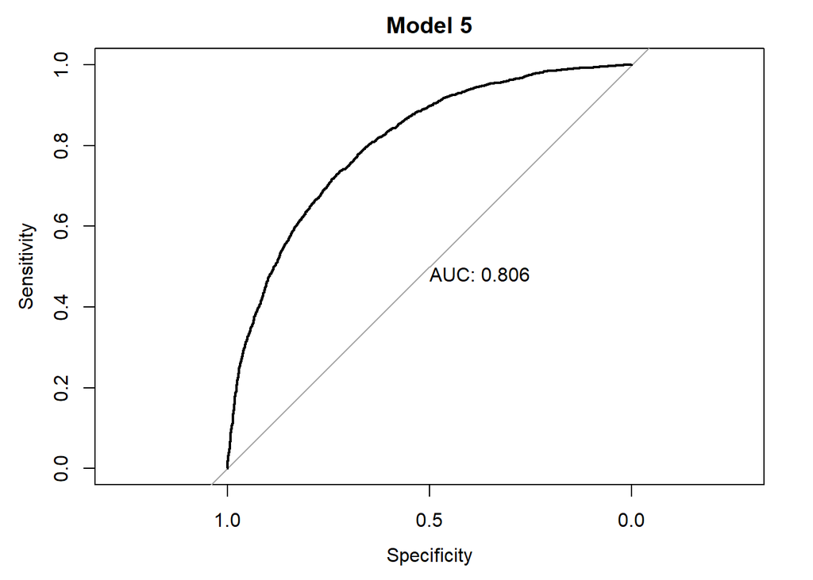

### **PREDICTION MODEDL 5**

```
## [1] "2058 not in a car crash and 83 in a car crash"
```

### **MUTIPLE LINEAR REGRESSION METRICS**

[output not shown]

### **RESIDUAL PLOT**

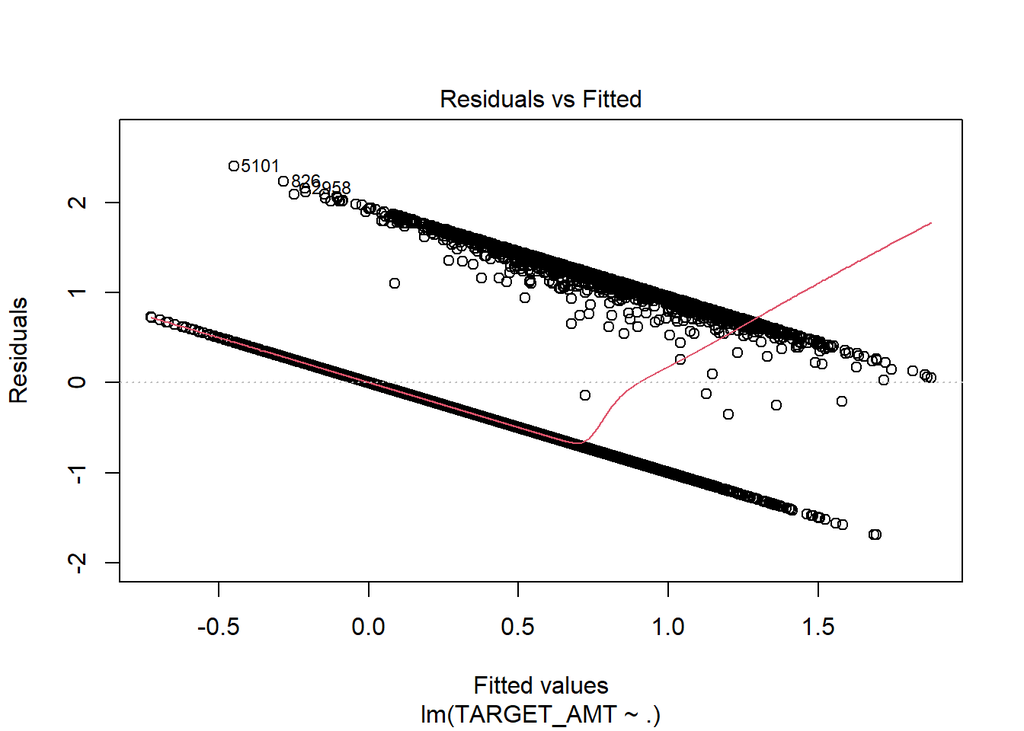

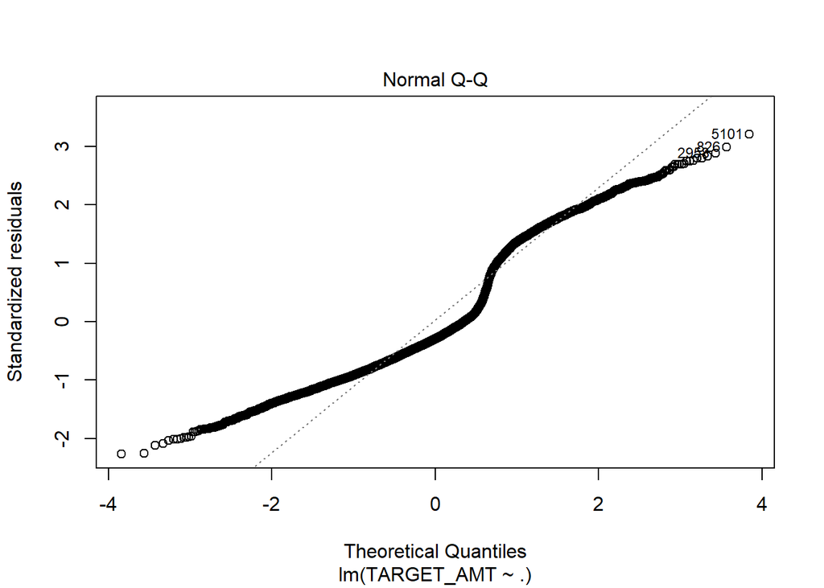

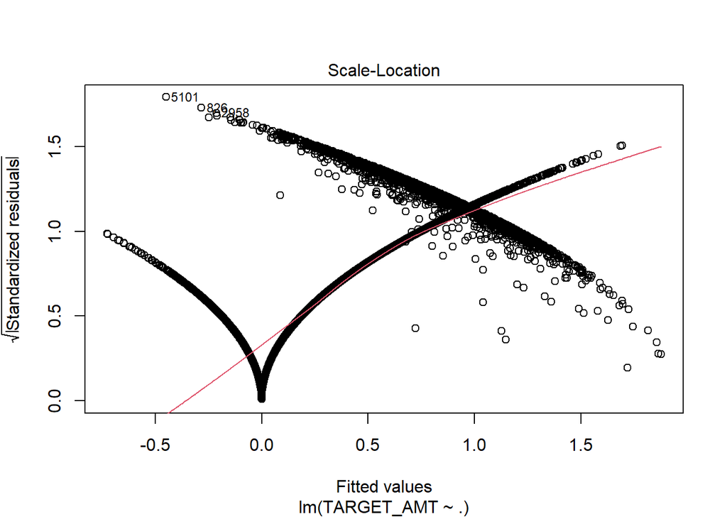

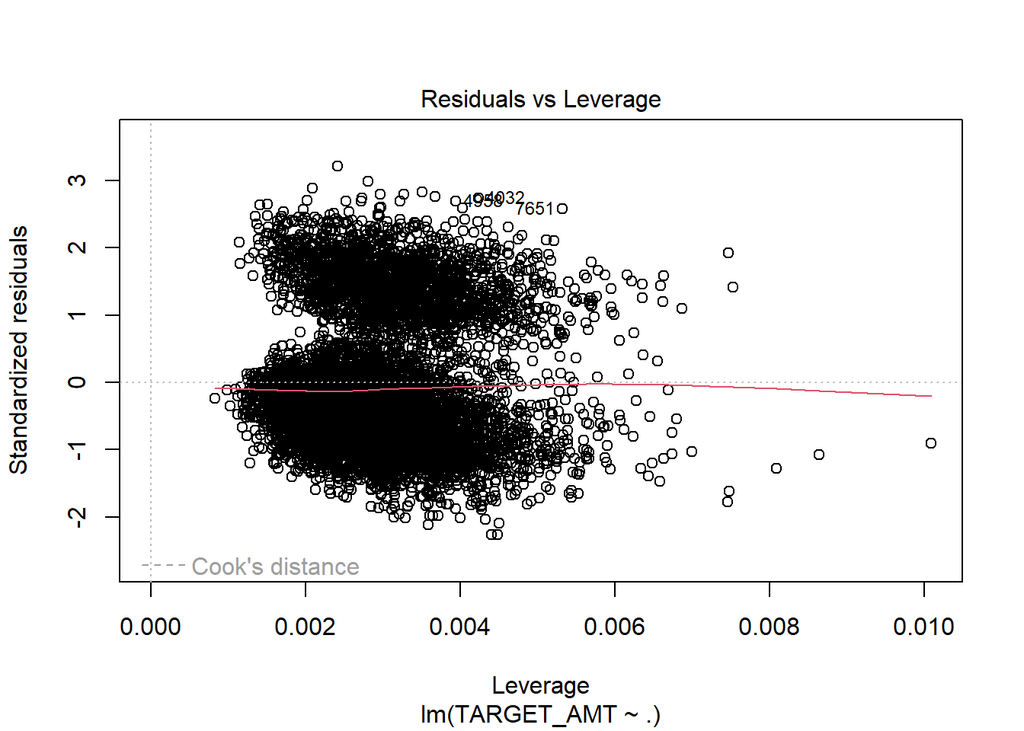

In the residual plot, I see that the variance of residuals are not uniform which indicates our explanatory variable is probably does not fully explain the data. Also the quartile-quartile plot, I see that the residuals are not normally distributed. Therefore, I would say overall this is not a good model.

### **PREDICTION MODEL 6**

```
## [1] "2066 not in a car crash and 75 in a car crash"
```

### **PREDICTION MODEL 7**

```
## [1] "1978 not in a car crash and 163 in a car crash"
```

## **CONCLUSION**

I explored, analyzed and modeled a data set containing information on insurance evaluation for various variables, which had some missing values and had some outliers. Some of the variables were normally distributed, while others were moderate to high skewness. There were positive correlation between variables and also moderate to negative correlations between variables.

I prepared the data by transforming the variables to build the models. I built the first model, Mutiple Linear Regression Model 1 by using the Origional Value Model. The second model I built, Mutiple Linear Regression Model 2 by Imputing Model. The third model I built, Mutiple Linear Regression Model 3 by using Stepwise Transformation. I built the fourth model, Mutiple Regression Model 4 by using BoxCox Transformation. I build the fifth model, Binary Logistic Regression Model 1 using Origional Value Model. The sixth model, Binary Logistic Regression Model 2, I built it by using The Stepwise Transformation. The seventh model, Binary Logistic Regression Model 3, I built it by using BoxCox Transformation.

Lastly, I did a prediction with Model 5, 2058 will not be in a car crash and 83 will be in a car crash. With Model 6, 2066 will not be in a car crash and 75 will be in a car crash. With Model 7, 1978 will not be in a car crash and 163 will be in a car crash.

## **APPENDIX: ALL CODES**

```r
knitr::opts_chunk$set(echo = FALSE)
# load libraries
suppressWarnings({
  # Code that generates specific warnings
  # Other code
  library(mice)
  library(tidyverse)
  library(psych)
  library(corrplot)
  library(RColorBrewer)
  library(knitr)
  library(MASS)
  library(caret)
  library(kableExtra)
  library(ResourceSelection)
  library(pROC)
  library(ggplot2)
  library(gridExtra)
  library(ggpubr)
})

suppressMessages({
  library(mice)
  library(tidyverse)
  library(psych)
  library(corrplot)
  library(RColorBrewer)
  library(knitr)
  library(MASS)
  library(caret)
  library(kableExtra)
  library(ResourceSelection)
  library(pROC)
  library(ggplot2)
  library(gridExtra)
  library(ggpubr)
  })

#load data
insurance_train<- read.csv("https://raw.githubusercontent.com/enidroman/DATA-621-Business-Analytics-and-Data-Mining/main/insurance_training_data.csv")
insurance_test <- read.csv("https://raw.githubusercontent.com/enidroman/DATA-621-Business-Analytics-and-Data-Mining/main/insurance-evaluation-data%20(1).csv")
vn <- c("INDEX","TARGET_FLAG", "TARGET_AMT", "AGE", "BLUEBOOK", "CAR_AGE", "CAR_TYPE", "CAR_USE", "CLM_FREQ", "EDUCATION", "HOMEKIDS", "HOME_VAL", "INCOME", "JOB", "KIDSDRIV", "MSTATUS", "MVR_PTS", "OLDCLAIM", "PARENT1", "RED_CAR", "REVOKED", "SEX", "TIF", "TRAVTIME", "URBANICITY", "YOJ")
defin <- c("Identification Variable (do not use)", "Was Car in a crash? 1=YES 0=NO", "If car was in a crash, what was the cost", "Age of Driver", "Value of Vehicle", "Vehicle Age", "Type of Car", "Vehicle Use", "# Claims (Past 5 Years)", "Max Education Level", "# Children at Home", "Home Value", "Income", "Job Category", "# Driving Children", "Marital Status", "Motor Vehicle Record Points", "Total Claims (Past 5 Years)", "Single Parent", "A Red Car", "License Revoked (Past 7 Years)", "Gender", "Time in Force", "Distance to Work", "Home/Work Area", "Years on Job")
theor_effect <- c("None", "None", "None", "Very young people tend to be risky. Maybe very old people also.", "Unknown effect on probability of collision, but probably effect the payout if there is a crash.", "Unknown effect on probability of collision, but probably effect the payout if there is a crash.", "Unknown effect on probability of collision, but probably effect the payout if there is a crash.", "Commercial vehicles are driven more, so might increase probability of collision.", "The more claims you filed in the past, the more you are likely to file in the future.", "Unknown effect, but in theory more educated people tend to drive more safely.", "Unknown effect", "In theory, home owners tend to drive more responsibly.", "In theory, rich people tend to get into fewer crashes.", "In theory, white collar jobs tend to be safer.", "When teenagers drive your car, you are more likely to get into crashes.", "In theory, married people drive more safely.", "If you get lots of traffic tickets, you tend to get into more crashes.", "If your total payout over the past five years was high, this suggests future payouts will be high.", "Unknown effect.", "Urban legend says that red cars (especially red sports cars) are more risky. Is that true?", "If your license was revoked in the past 7 years, you probably are a more risky driver.", "Urban legend says that women have less crashes then men. Is that true?", "People who have been customers for a long time are usually more safe.", "Long drives to work usually suggest greater risk.", "Unknown", "People who stay at a job for a long time are usually more safe.")
kable(cbind(vn, defin, theor_effect), col.names = c("VARIABLE NAME", "DEFINITION", "THEORETICAL EFFECT")) %>%
  kable_styling(full_width = T)
# summary statistics
insurance_train %>%
  mutate(target_amt = as.factor(TARGET_AMT),
         target = as.factor(TARGET_FLAG)) %>%
  describe()
summary(insurance_train)
str(insurance_train)
# count the total number of missing values
sum(is.na(insurance_train))
custom_theme <- theme_minimal() +
  theme(
    text = element_text(family = "serif"),
    plot.title = element_text(face = "bold", size = 14, hjust = 0.5),
    axis.title = element_text(face = "bold"),
    axis.text = element_text(size = 10),
    axis.text.x = element_text(angle = 45, hjust = 1)
  )

insurance_train %>%
  mutate(TARGET_FLAG = as.factor(TARGET_FLAG)) %>%
  ggplot(aes(x = TARGET_FLAG, fill = TARGET_FLAG)) +
  geom_bar() + scale_y_continuous() +
  custom_theme +
  theme(legend.position = "none") +
  labs(x = "TARGET_FLAG", y = "n()") +
  labs(title = "TARGET_FLAG") -> p1

insurance_train %>% filter(TARGET_FLAG == 1) %>%
  ggplot(aes(x = 1, y = TARGET_AMT)) +
  geom_boxplot() +
  stat_summary(fun.y = "mean", geom = "point", shape = 23, size = 3, fill = "#FF2700") +
  scale_x_continuous(breaks = NULL) +
  custom_theme +
  labs(title = "TARGET_AMT") -> p2

insurance_train %>% filter(TARGET_FLAG == 1) %>%
  ggplot(aes(x = 1, y = TARGET_AMT)) +
  geom_boxplot() +
  stat_summary(fun.y = "mean", geom = "point", shape = 23, size = 3, fill = "#008FD5") +
  scale_y_continuous(limits = quantile(insurance_train$TARGET_AMT, c(0.1, 0.9))) +
  scale_x_continuous(breaks = NULL) +
  custom_theme +
  labs(title = "TARGET_AMT - No outliers") -> p3

grid.arrange(p1, p2, p3, ncol = 3)

# change data type of some variables for visualization
insurance_train <- insurance_train %>%
  dplyr::select(-INDEX) %>%
  mutate(TARGET_FLAG = as.factor(TARGET_FLAG),
         KIDSDRIV = as.factor(KIDSDRIV),
         HOMEKIDS = as.factor(HOMEKIDS),
         PARENT1 = as.factor(PARENT1),
         CLM_FREQ = as.factor(CLM_FREQ),
         INCOME = str_replace_all(INCOME, "[\\$,]", ""),
         HOME_VAL = str_replace_all(HOME_VAL, "[\\$,]", ""),
         BLUEBOOK = str_replace_all(BLUEBOOK, "[\\$,]", ""),
         OLDCLAIM = str_replace_all(OLDCLAIM, "[\\$,]", ""),
         OLDCLAIM = as.integer(OLDCLAIM),
         BLUEBOOK = as.integer(BLUEBOOK),
         HOME_VAL = as.integer(HOME_VAL),
         INCOME = as.integer(INCOME))
# Distribution of discrete variables
k <- insurance_train %>%
  ggplot(aes(KIDSDRIV, fill = TARGET_FLAG)) +
  geom_bar(position = position_dodge()) +
  theme(legend.position = "none")
```

```r
hk <- insurance_train %>%
  ggplot(aes(HOMEKIDS, fill = TARGET_FLAG)) +
  geom_bar(position = position_dodge()) +
  theme(legend.position = "none")

p <- insurance_train %>%
  ggplot(aes(PARENT1, fill = TARGET_FLAG)) +
  geom_bar(position = position_dodge()) +
  theme(legend.position = "none")

m <- insurance_train %>%
  ggplot(aes(MSTATUS, fill = TARGET_FLAG)) +
  geom_bar(position = position_dodge()) +
  theme(legend.position = "none")

s <- insurance_train %>%
  ggplot(aes(SEX, fill = TARGET_FLAG)) +
  geom_bar(position = position_dodge()) +
  theme(legend.position = "none")

e <- insurance_train %>%
  ggplot(aes(EDUCATION, fill = TARGET_FLAG)) +
  geom_bar(position = position_dodge()) +
  theme(legend.position = "none")

j <- insurance_train %>%
  ggplot(aes(JOB, fill = TARGET_FLAG)) +
  geom_bar(position = position_dodge()) +
  theme(axis.text.x = element_text(angle = 45, hjust = 1),
        legend.position = "none")

cu <- insurance_train %>%
  ggplot(aes(CAR_USE, fill = TARGET_FLAG)) +
  geom_bar(position = position_dodge()) +
  theme(legend.position = "none")

ct <- insurance_train %>%
  ggplot(aes(CAR_TYPE, fill = TARGET_FLAG)) +
  geom_bar(position = position_dodge()) +
  theme(legend.position = "none")

rc <- insurance_train %>%
  ggplot(aes(RED_CAR, fill = TARGET_FLAG)) +
  geom_bar(position = position_dodge()) +
  theme(legend.position = "none")

r <- insurance_train %>%
  ggplot(aes(REVOKED, fill = TARGET_FLAG)) +
  geom_bar(position = position_dodge()) +
  theme(legend.position = "none")

uc <- insurance_train %>%
  ggplot(aes(URBANICITY, fill = TARGET_FLAG)) +
  geom_bar(position = position_dodge()) +
  theme(legend.position = "none")

cf <- insurance_train %>%
  ggplot(aes(CLM_FREQ, fill = TARGET_FLAG)) +
  geom_bar(position = position_dodge()) +
  theme(legend.position = "none")

# Arrange plots
ggarrange(k, nrow =1)
ggarrange(hk,nrow =1)
ggarrange(p, nrow =1)
ggarrange(m, nrow =1)
ggarrange(s, nrow =1)
ggarrange(e, nrow =1)
ggarrange(j, nrow =1)
ggarrange(cu,nrow =1)
ggarrange(ct,nrow =1)
ggarrange(rc,nrow =1)
ggarrange(r, nrow =1)
ggarrange(uc,nrow =1)
ggarrange(cf,nrow =1)

# Change data type of some variables for visualization
distribution <- insurance_train %>%
  dplyr::select(c("TARGET_FLAG", "AGE", "YOJ", "INCOME", "HOME_VAL", "TRAVTIME", "BLUEBOOK", "TIF", "OLDCLAIM", "MVR_PTS", "CAR_AGE")) %>%
  gather(key, value, -TARGET_FLAG) %>%
  mutate(value = as.integer(value),
         key = as.factor(key),
         TARGET_FLAG = as.factor(TARGET_FLAG))


DataExplorer::plot_bar(
  data = insurance_train,
         order_bar = T,
         ggtheme=theme_bw())

# histogram of continous variables
distribution %>%
  ggplot(aes(value)) +
  facet_wrap(~key, scale = "free",  ncol = 3) +
  geom_histogram(binwidth = function(x) 2 * IQR(x) / (length(x)^(1/3)), fill="#56B4E9") +
  theme_minimal()

# boxplot of continous variables
distribution %>%
  ggplot(aes(x = key, y = value)) +
  geom_boxplot(aes(fill = TARGET_FLAG)) +
  facet_wrap(~ key, scales = 'free', ncol = 3) +
  scale_fill_manual(values=c("#999999", "#E69F00")) +
  theme_minimal()


insurance_train %>%
  keep(is.numeric) %>%
  gather(variable, value, -TARGET_AMT) %>%
  ggplot(., aes(value, TARGET_AMT)) +
  geom_point() +
  scale_color_brewer(palette="Set1") +
  theme_light() +
  theme(legend.position = "none") +
  facet_wrap(~variable, scales ="free", ncol = 4) +
  labs(x = element_blank(), y = element_blank())
# change all variable's data type for correlation
insurance_corr <- data.frame(lapply(insurance_train, function(x) as.numeric(as.factor(x))))
# top correlated variables
a <- sort(cor(dplyr::select(insurance_corr, TARGET_FLAG, everything()))[,1], decreasing = T)
b <- sort(cor(dplyr::select(insurance_corr, TARGET_AMT, everything()))[,1], decreasing = T)
kable(cbind(a, b), col.names = c("TARGET_FLAG", "TARGET_AMT")) %>%
  kable_styling(full_width = F) %>%
  add_header_above(c(" ", "Correlation" = 2))
# correlation plot
corrplot(cor(dplyr::select(drop_na(insurance_corr), everything())),
         method = "number",
         type = "lower",
         col = brewer.pal(n = 26, name = "Paired"),
         number.cex = .7, tl.cex = .7,
         tl.col = "black", tl.srt = 45)

insurance_train_new <- insurance_train %>%
  mutate(INCOME =as.numeric(str_replace_all(INCOME,'([\\$,])',''))/1000) %>%
  mutate(HOME_VAL =as.numeric(str_replace_all(HOME_VAL,'([\\$,])',''))/1000) %>%
  mutate(BLUEBOOK =as.numeric(str_replace_all(BLUEBOOK,'([\\$,])',''))/1000) %>%
  mutate(OLDCLAIM =as.numeric(str_replace_all(OLDCLAIM,'([\\$,])',''))/1000) %>%
  mutate(MSTATUS =as.factor(str_replace_all(MSTATUS,'([z_<])',''))) %>%
  mutate(SEX =as.factor(str_replace_all(SEX,'([z_<])',''))) %>%
  mutate(EDUCATION =as.factor(str_replace_all(EDUCATION,'([z_<])',''))) %>%
  mutate(JOB = as.factor(str_replace_all(JOB,'([z_<])',''))) %>%
  mutate(CAR_TYPE = as.factor(str_replace_all(CAR_TYPE,'([z_<])',''))) %>%
  mutate(URBANICITY = as.factor(str_replace_all(URBANICITY,'([z_<])',''))) %>%
  mutate(CAR_AGE = if_else(is.na(CAR_AGE),median(CAR_AGE,na.rm=TRUE),CAR_AGE)) %>%
  mutate(CAR_AGE = if_else(CAR_AGE<0,median(CAR_AGE,na.rm=TRUE),CAR_AGE)) %>%
  mutate(YOJ = if_else(is.na(YOJ),median(YOJ,na.rm=TRUE),YOJ)) %>%
  mutate(AGE = if_else(is.na(AGE),median(AGE,na.rm=TRUE),AGE)) %>%
  mutate(INCOME = if_else(is.na(INCOME),median(INCOME,na.rm=TRUE),INCOME)) %>%
  mutate(HOME_VAL = if_else(is.na(HOME_VAL),median(HOME_VAL,na.rm=TRUE),HOME_VAL))


# Order EDUCATION FACTOR

   insurance_train$EDUCATION <- ordered(insurance_train$EDUCATION, levels = c("High School", "Bachelors", "Masters", "PhD") )

# summary statistics
insurance_train_new %>%
  mutate(target_amt = as.factor(TARGET_AMT),
         target = as.factor(TARGET_FLAG)) %>%
  describe()
summary(insurance_train_new)
str(insurance_train_new)
# count the total number of missing values
sum(is.na(insurance_train_new))
set.seed(123)
init <- mice(insurance_train_new)
meth <- init$method
predM <- init$predictorMatrix
predM[, c("TARGET_FLAG", "TARGET_AMT")] <- 0 #this code will remove the variable as a predictor but still will be imputed
insurance_impute <- mice(insurance_train_new, method = 'rf', predictorMatrix=predM)
insurance_imputed <- complete(insurance_impute)
print(paste0("Missing value after imputation: ", sum(is.na(insurance_imputed))))
```

```r
insurance_test <- insurance_test %>%
  dplyr::select(-c(TARGET_FLAG, TARGET_AMT, INDEX)) %>%
  mutate(KIDSDRIV = as.factor(KIDSDRIV),
         HOMEKIDS = as.factor(HOMEKIDS),
         PARENT1 = as.factor(PARENT1),
         CLM_FREQ = as.factor(CLM_FREQ),
         INCOME = str_replace_all(INCOME, "[\\$,]", ""),
         HOME_VAL = str_replace_all(HOME_VAL, "[\\$,]", ""),
         BLUEBOOK = str_replace_all(BLUEBOOK, "[\\$,]", ""),
         OLDCLAIM = str_replace_all(OLDCLAIM, "[\\$,]", ""),
         OLDCLAIM = as.integer(OLDCLAIM),
         BLUEBOOK = as.integer(BLUEBOOK),
         HOME_VAL = as.integer(HOME_VAL),
         INCOME = as.integer(INCOME))
# imputating evaluation data
init <- mice(insurance_test)
meth <- init$method
predM <- init$predictorMatrix
insurance_eval_impute <- mice(insurance_test, method = 'rf', predictorMatrix=predM)
insurance_eval_imputed <- complete(insurance_eval_impute)
insurance_eval_imputed <- data.frame(lapply(insurance_eval_imputed, function(x) as.numeric(as.factor(x))))
print(paste0("Missing value after imputation: ", sum(is.na(insurance_eval_imputed))))

insurance_vif <- data.frame(lapply(insurance_imputed, function(x) as.numeric(as.factor(x))))
kable((car::vif(glm(TARGET_FLAG ~. , data = insurance_vif))), col.names = c("VIF Score")) %>%  #remove tax for high vif score
  kable_styling(full_width = F)
insurance_corr <- dplyr::select(insurance_corr, -"TARGET_FLAG")
model1 <- lm(TARGET_AMT ~ ., insurance_corr)
summary(model1)
insurance_vif <- dplyr::select(insurance_vif, -"TARGET_FLAG")
model2 <- lm(TARGET_AMT ~ ., insurance_vif)
summary(model2)
model3 <- stepAIC(model2, direction = "both", trace = FALSE)
summary(model3)
insurance_boxcox <- preProcess(insurance_vif, c("BoxCox"))
in_bc_transformed <- predict(insurance_boxcox, insurance_vif)
model4 <- lm(TARGET_AMT ~ ., in_bc_transformed)
summary(model4)
logit_data <- data.frame(lapply(insurance_imputed, function(x) as.numeric(as.factor(x)))) %>%
  mutate(TARGET_FLAG = as.factor(TARGET_FLAG)) %>%
  dplyr::select(-"TARGET_AMT")
model5 <- glm(TARGET_FLAG ~ ., family = "binomial", logit_data)
summary(model5)
model6 <- stepAIC(model5, direction = "both", trace = FALSE)
summary(model6)
insurance_boxcox1 <- preProcess(logit_data, c("BoxCox"))
in_bc_transformed1 <- predict(insurance_boxcox1, logit_data)
model7 <- glm(TARGET_FLAG ~ ., family = "binomial", in_bc_transformed1)
summary(model7)
# comparing all binary logistic models using various measures
c1 <- confusionMatrix(as.factor(as.integer(fitted(model5) > .5)), as.factor(model5$y), positive = "1")
c2 <- confusionMatrix(as.factor(as.integer(fitted(model6) > .5)), as.factor(model6$y), positive = "1")
c3 <- confusionMatrix(as.factor(as.integer(fitted(model7) > .5)), as.factor(model7$y), positive = "1")

roc1 <- roc(logit_data$TARGET_FLAG,  predict(model5, logit_data, interval = "prediction"))
roc2 <- roc(logit_data$TARGET_FLAG,  predict(model6, logit_data, interval = "prediction"))
roc3 <- roc(logit_data$TARGET_FLAG,  predict(model7, logit_data, interval = "prediction"))

metrics1 <- c(c1$overall[1], "Class. Error Rate" = 1 - as.numeric(c1$overall[1]), c1$byClass[c(1, 2, 5, 7)], AUC = roc1$auc)
metrics2 <- c(c2$overall[1], "Class. Error Rate" = 1 - as.numeric(c2$overall[1]), c2$byClass[c(1, 2, 5, 7)], AUC = roc2$auc)
metrics3 <- c(c3$overall[1], "Class. Error Rate" = 1 - as.numeric(c3$overall[1]), c3$byClass[c(1, 2, 5, 7)], AUC = roc3$auc)

kable(cbind(metrics1, metrics2, metrics3), col.names = c("Model 5", "Model 6", "Model 7"))  %>%
  kable_styling(full_width = T)


plot(roc(logit_data$TARGET_FLAG,  predict(model5, logit_data, interval = "prediction")), print.auc = TRUE, main = "Model 5" )
# predict
predict <- predict(model5, insurance_eval_imputed, interval = "prediction")
eval <- table(as.integer(predict > .5))
print(paste(eval[1], "not in a car crash", "and", eval[2], "in a car crash"))
a1 <- mean((summary(model1))$residuals^2)
a2 <- mean((summary(model2))$residuals^2)
a3 <- mean((summary(model3))$residuals^2)
a4 <- mean((summary(model4))$residuals^2)
a5 <- rbind(a1, a2, a3, a4)

b1 <- summary(model2)$r.squared
b2 <- summary(model3)$r.squared
b3 <- summary(model1)$r.squared
b4 <- summary(model4)$r.squared
b5 <- rbind(b1, b2, b3, b4)

c1 <- summary(model1)$fstatistic
c2 <- summary(model2)$fstatistic
c3 <- summary(model3)$fstatistic
c4 <- summary(model4)$fstatistic
c5 <- rbind(c1, c2, c3, c4)

mlr_metrics <- data.frame(cbind(a5, b5, c5), row.names = c("Model 1", "Model 2", "Model 3", "Model 4"))
colnames(mlr_metrics) <- c("MSE", "R-Squared", "value", "numdf", "dendf")
kable(mlr_metrics) %>%
  kable_styling(full_width = T) %>%
  add_header_above(c(" ", " " = 2, "F-Statistic" = 3))
plot(model4)
# predict
predict <- predict(model6, insurance_eval_imputed, interval = "prediction")
eval <- table(as.integer(predict > .5))
print(paste(eval[1], "not in a car crash", "and", eval[2], "in a car crash"))
# predict
predict <- predict(model7, insurance_eval_imputed, interval = "prediction")
eval <- table(as.integer(predict > .5))
print(paste(eval[1], "not in a car crash", "and", eval[2], "in a car crash"))
```